# 학생음주분석

## 인사이트

##### 남학생이 여학생보다 알콜 소비량이 주중 주말 상관없이 높다

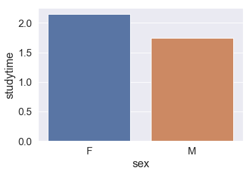

```python
sns.barplot(data=sex_study, x="sex", y="studytime")
plt.show()
# 남여 학생의 공부시간 평균 시각화
```

## 인사이트

##### 여학생의 공부시간이 남학생보다 평균적으로 높다

```python
fe_romantic = raw_data[raw_data["sex"] == "F"].romantic
fe_romantic.head()
# 여성의 연애 현황을 추출
```

```
0     no
1     no
2     no
3    yes
4     no
Name: romantic, dtype: object
```

```python
# type(fe_romantic) 타입을 확인한 후 프레임 변환
fe_romantic = fe_romantic.to_frame()
fe_romantic.head()
# 시리즈 타입으로 시각화를 위해 데이터프레임 형태로 변경
```

|  | romantic |
| --- | --- |
| 0 | no |
| 1 | no |
| 2 | no |
| 3 | yes |
| 4 | no |

```python
ma_romantic = raw_data[raw_data["sex"] == "M"].romantic
ma_romantic.head()
```

```
5     no
6     no
8     no
9     no
12    no
Name: romantic, dtype: object
```

```python
# type(ma_romantic)
ma_romantic = ma_romantic.to_frame()
ma_romantic.head()
# 시리즈 타입으로 시각화를 위해 데이터프레임 형태로 변경
```

|  | romantic |
| --- | --- |
| 5 | no |
| 6 | no |
| 8 | no |
| 9 | no |
| 12 | no |

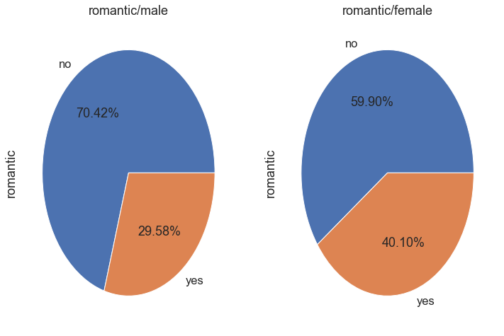

```python
# 성별에 따른 연애 상태를 pie 그래프로 시각화
x, ax = plt.subplots(1, 2, figsize=(12, 8)) # subplots는 리턴값이 2개라서 하나를 x에 담아줌.
ma_romantic["romantic"].value_counts().plot.pie(autopct="%1.2f%%", ax=ax[0]) # autopct 그래프 위에 수치 찍어줌.
fe_romantic["romantic"].value_counts().plot.pie(autopct="%1.2f%%", ax=ax[1])
ax[0].set_title("romantic/male")
ax[1].set_title("romantic/female")
plt.show()
```

## 인사이트

##### 과반수 이상의 학생은 연애를 하지 않는다.

##### 연애하는 학생의 비율은 남학생보다 여학생이 높다.

```python
ma_fail = raw_data[raw_data["sex"] == "M"].failures
ma_fail = ma_fail.to_frame()
ma_fail.head()
# 남학생의 클래스 실패 횟수
```

|  | failures |
| --- | --- |
| 5 | 0 |
| 6 | 0 |
| 8 | 0 |
| 9 | 0 |
| 12 | 0 |

```python
fe_fail = raw_data[raw_data["sex"] == "F"].failures
fe_fail = fe_fail.to_frame()
fe_fail.head()
# 여학생의 클래스 실패 횟수
```

|  | failures |
| --- | --- |
| 0 | 0 |
| 1 | 0 |
| 2 | 0 |
| 3 | 0 |
| 4 | 0 |

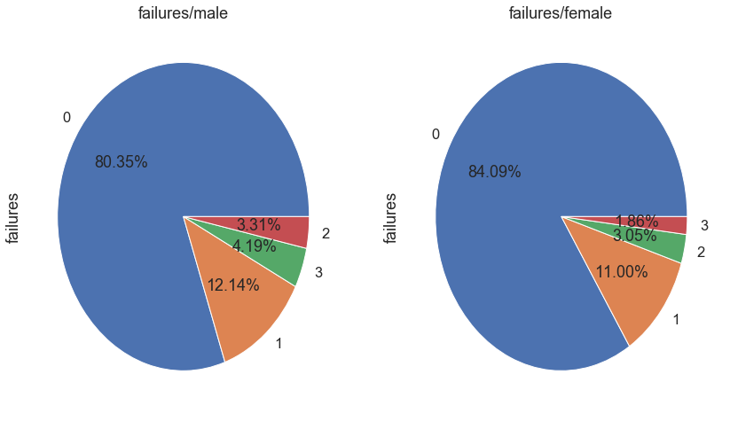

```python
# 성별에 따른 클래스 실패 횟수를 pie 그래프로 시각화
x, ax = plt.subplots(1, 2, figsize=(14, 8)) # subplots는 리턴값이 2개라서 하나를 x에 담아줌.
ma_fail["failures"].value_counts().plot.pie(autopct="%1.2f%%", ax=ax[0])
fe_fail["failures"].value_counts().plot.pie(autopct="%1.2f%%", ax=ax[1])
ax[0].set_title("failures/male")
ax[1].set_title("failures/female")
plt.show()
```

## 인사이트

##### 클래스실패(과락/유급)의 경험은 남학생이 약 20% 여학생이 약 16%로 남학생이 더 많이 클래스 실패를 경험함

##### 클래스 실패의 횟수의 비율은 1회는 비슷하나 3회는 남학생이 약 2배 정도 더 많이 경험함

```python
drink_possible = []
# 파생변수를 만들어서 술을 먹고 안먹고를 정해줌.
```

```python
raw_data["Dalc"][1] # 파생변수를 만들기 위한 조건으로 어떤값이 나오는지 확인.
```

```
1
```

```python
for i in range(len(raw_data)):
    if raw_data["Dalc"][i] + raw_data["Walc"][i] > 2:
               drink_possible.append("1")
    else:
        drink_possible.append("0")
# raw_data에 술을 먹고 안먹고의 데이터가 없어서 주중 주말 둘다 1을 체크한 사람을 알콜소비가 없다고 가정
# 새로운 파생변수를 만들어서 데이터를 넣어준다.
# drink_possible 1은 술을 먹는 사람 0은 술을 안먹는 사람으로 분류
```

```python
drink_possible
# 데이터 값 확인
```

```
['0',
 '0',
 '1',
 '0',
 '1',
 '1',
 '0',
 '0',
 '0',
 '0',
 '1',
 '0',
 '1',
 '1',
 '0',
 '1',
 '1',
 '0',
 '1',
 '1',
 '0',
 '0',
 '1',
 '1',
 '0',
 '1',
 '1',
 '1',
 '0',
 '1',
 '1',
 '0',
 '0',
 '0',
 '0',
 '0',
 '0',
 '0',
 '0',
 '0',
```

[output cut: 946 more lines]

```
 '1',
 '0',
 '1',
 '1',
 '1',
 '1',
 '1',
 '1',
 '1',
 '1',
 '1',
 '1',
 '1',
 '1',
 ...]
```

```python
type(drink_possible)
```

```
list
```

```python
raw_data["drink_possible"] = drink_possible
# 파생변수로 열을 만들어서 raw_data에 추가해준다. 음주를 하는지 안하는지를 확인할 수 있다.
raw_data
# 데이터프레임 출력으로 파생변수 잘 만들어 졌는지 확인
```

|  | sex | age | address | famsize | Pstatus | Medu | Fedu | Mjob | Fjob | guardian | ... | internet | romantic | famrel | freetime | goout | Dalc | Walc | health | absences | drink_possible |
| --- | --- | --- | --- | --- | --- | --- | --- | --- | --- | --- | --- | --- | --- | --- | --- | --- | --- | --- | --- | --- | --- |
| 0 | F | 18 | U | GT3 | A | 4 | 4 | at_home | teacher | mother | ... | no | no | 4 | 3 | 4 | 1 | 1 | 3 | 4 | 0 |
| 1 | F | 17 | U | GT3 | T | 1 | 1 | at_home | other | father | ... | yes | no | 5 | 3 | 3 | 1 | 1 | 3 | 2 | 0 |
| 2 | F | 15 | U | LE3 | T | 1 | 1 | at_home | other | mother | ... | yes | no | 4 | 3 | 2 | 2 | 3 | 3 | 6 | 1 |
| 3 | F | 15 | U | GT3 | T | 4 | 2 | health | services | mother | ... | yes | yes | 3 | 2 | 2 | 1 | 1 | 5 | 0 | 0 |
| 4 | F | 16 | U | GT3 | T | 3 | 3 | other | other | father | ... | no | no | 4 | 3 | 2 | 1 | 2 | 5 | 0 | 1 |
| 5 | M | 16 | U | LE3 | T | 4 | 3 | services | other | mother | ... | yes | no | 5 | 4 | 2 | 1 | 2 | 5 | 6 | 1 |
| 6 | M | 16 | U | LE3 | T | 2 | 2 | other | other | mother | ... | yes | no | 4 | 4 | 4 | 1 | 1 | 3 | 0 | 0 |
| 7 | F | 17 | U | GT3 | A | 4 | 4 | other | teacher | mother | ... | no | no | 4 | 1 | 4 | 1 | 1 | 1 | 2 | 0 |
| 8 | M | 15 | U | LE3 | A | 3 | 2 | services | other | mother | ... | yes | no | 4 | 2 | 2 | 1 | 1 | 1 | 0 | 0 |
| 9 | M | 15 | U | GT3 | T | 3 | 4 | other | other | mother | ... | yes | no | 5 | 5 | 1 | 1 | 1 | 5 | 0 | 0 |
| 10 | F | 15 | U | GT3 | T | 4 | 4 | teacher | health | mother | ... | yes | no | 3 | 3 | 3 | 1 | 2 | 2 | 2 | 1 |
| 11 | F | 15 | U | GT3 | T | 2 | 1 | services | other | father | ... | yes | no | 5 | 2 | 2 | 1 | 1 | 4 | 0 | 0 |
| 12 | M | 15 | U | LE3 | T | 4 | 4 | health | services | father | ... | yes | no | 4 | 3 | 3 | 1 | 3 | 5 | 0 | 1 |
| 13 | M | 15 | U | GT3 | T | 4 | 3 | teacher | other | mother | ... | yes | no | 5 | 4 | 3 | 1 | 2 | 3 | 0 | 1 |
| 14 | M | 15 | U | GT3 | A | 2 | 2 | other | other | other | ... | yes | yes | 4 | 5 | 2 | 1 | 1 | 3 | 0 | 0 |
| 15 | F | 16 | U | GT3 | T | 4 | 4 | health | other | mother | ... | yes | no | 4 | 4 | 4 | 1 | 2 | 2 | 6 | 1 |
| 16 | F | 16 | U | GT3 | T | 4 | 4 | services | services | mother | ... | yes | no | 3 | 2 | 3 | 1 | 2 | 2 | 10 | 1 |
| 17 | F | 16 | U | GT3 | T | 3 | 3 | other | other | mother | ... | no | no | 5 | 3 | 2 | 1 | 1 | 4 | 2 | 0 |
| 18 | M | 17 | U | GT3 | T | 3 | 2 | services | services | mother | ... | yes | no | 5 | 5 | 5 | 2 | 4 | 5 | 2 | 1 |
| 19 | M | 16 | U | LE3 | T | 4 | 3 | health | other | father | ... | yes | no | 3 | 1 | 3 | 1 | 3 | 5 | 6 | 1 |
| 20 | M | 15 | U | GT3 | T | 4 | 3 | teacher | other | mother | ... | yes | no | 4 | 4 | 1 | 1 | 1 | 1 | 0 | 0 |
| 21 | M | 15 | U | GT3 | T | 4 | 4 | health | health | father | ... | yes | no | 5 | 4 | 2 | 1 | 1 | 5 | 0 | 0 |
| 22 | M | 16 | U | LE3 | T | 4 | 2 | teacher | other | mother | ... | yes | no | 4 | 5 | 1 | 1 | 3 | 5 | 0 | 1 |
| 23 | M | 16 | U | LE3 | T | 2 | 2 | other | other | mother | ... | yes | no | 5 | 4 | 4 | 2 | 4 | 5 | 2 | 1 |
| 24 | F | 15 | R | GT3 | T | 2 | 4 | services | health | mother | ... | yes | no | 4 | 3 | 2 | 1 | 1 | 5 | 2 | 0 |
| 25 | F | 16 | U | GT3 | T | 2 | 2 | services | services | mother | ... | yes | no | 1 | 2 | 2 | 1 | 3 | 5 | 6 | 1 |
| 26 | M | 15 | U | GT3 | T | 2 | 2 | other | other | mother | ... | yes | no | 4 | 2 | 2 | 1 | 2 | 5 | 8 | 1 |
| 27 | M | 15 | U | GT3 | T | 4 | 2 | health | services | mother | ... | yes | no | 2 | 2 | 4 | 2 | 4 | 1 | 0 | 1 |
| 28 | M | 16 | U | LE3 | A | 3 | 4 | services | other | mother | ... | yes | no | 5 | 3 | 3 | 1 | 1 | 5 | 2 | 0 |
| 29 | M | 16 | U | GT3 | T | 4 | 4 | teacher | teacher | mother | ... | yes | yes | 4 | 4 | 5 | 5 | 5 | 5 | 4 | 1 |
| ... | ... | ... | ... | ... | ... | ... | ... | ... | ... | ... | ... | ... | ... | ... | ... | ... | ... | ... | ... | ... | ... |
| 1014 | M | 18 | R | GT3 | T | 1 | 3 | at_home | other | mother | ... | no | no | 3 | 3 | 4 | 2 | 4 | 3 | 4 | 1 |
| 1015 | M | 18 | U | LE3 | T | 4 | 4 | teacher | services | mother | ... | yes | yes | 4 | 2 | 2 | 2 | 2 | 5 | 0 | 1 |
| 1016 | F | 17 | R | GT3 | T | 1 | 1 | other | services | mother | ... | yes | yes | 5 | 2 | 1 | 1 | 2 | 1 | 0 | 1 |
| 1017 | F | 18 | U | GT3 | T | 2 | 3 | at_home | services | father | ... | yes | yes | 5 | 2 | 3 | 1 | 2 | 4 | 0 | 1 |
| 1018 | F | 18 | R | GT3 | T | 4 | 4 | other | teacher | father | ... | yes | yes | 3 | 2 | 2 | 4 | 2 | 5 | 10 | 1 |
| 1019 | F | 19 | U | LE3 | T | 3 | 2 | services | services | other | ... | no | yes | 3 | 2 | 2 | 1 | 1 | 3 | 4 | 0 |
| 1020 | M | 18 | R | LE3 | T | 1 | 2 | at_home | services | father | ... | yes | yes | 4 | 3 | 3 | 2 | 3 | 3 | 3 | 1 |
| 1021 | F | 17 | U | GT3 | T | 2 | 2 | other | at_home | mother | ... | no | yes | 3 | 4 | 3 | 1 | 1 | 3 | 8 | 0 |
| 1022 | F | 17 | R | GT3 | T | 1 | 2 | other | other | mother | ... | yes | no | 3 | 5 | 5 | 1 | 3 | 1 | 14 | 1 |
| 1023 | F | 18 | R | LE3 | T | 4 | 4 | other | other | mother | ... | yes | no | 5 | 4 | 4 | 1 | 1 | 1 | 0 | 0 |
| 1024 | F | 18 | R | GT3 | T | 1 | 1 | other | other | mother | ... | yes | no | 4 | 3 | 2 | 1 | 2 | 4 | 2 | 1 |
| 1025 | F | 20 | U | GT3 | T | 4 | 2 | health | other | other | ... | yes | yes | 5 | 4 | 3 | 1 | 1 | 3 | 4 | 0 |
| 1026 | F | 18 | R | LE3 | T | 4 | 4 | teacher | services | mother | ... | yes | no | 5 | 4 | 3 | 3 | 4 | 2 | 4 | 1 |
| 1027 | F | 18 | U | GT3 | T | 3 | 3 | other | other | mother | ... | yes | yes | 4 | 1 | 3 | 1 | 2 | 1 | 0 | 1 |
| 1028 | F | 17 | R | GT3 | T | 3 | 1 | at_home | other | mother | ... | yes | no | 4 | 5 | 4 | 2 | 3 | 1 | 17 | 1 |
| 1029 | M | 18 | U | GT3 | T | 4 | 4 | teacher | teacher | father | ... | yes | no | 3 | 2 | 4 | 1 | 4 | 2 | 4 | 1 |
| 1030 | M | 18 | R | GT3 | T | 2 | 1 | other | other | mother | ... | yes | yes | 4 | 4 | 3 | 1 | 3 | 5 | 5 | 1 |
| 1031 | M | 17 | U | GT3 | T | 2 | 3 | other | services | father | ... | yes | no | 4 | 4 | 3 | 1 | 1 | 3 | 2 | 0 |
| 1032 | M | 19 | R | GT3 | T | 1 | 1 | other | services | mother | ... | no | no | 4 | 3 | 2 | 1 | 3 | 5 | 0 | 1 |
| 1033 | M | 18 | R | GT3 | T | 4 | 2 | other | other | father | ... | no | no | 5 | 4 | 3 | 4 | 3 | 3 | 14 | 1 |
| 1034 | F | 18 | R | GT3 | T | 2 | 2 | at_home | other | mother | ... | no | no | 5 | 3 | 3 | 1 | 3 | 4 | 2 | 1 |
| 1035 | F | 18 | R | GT3 | T | 4 | 4 | teacher | at_home | mother | ... | yes | yes | 4 | 4 | 3 | 2 | 2 | 5 | 7 | 1 |
| 1036 | F | 19 | R | GT3 | T | 2 | 3 | services | other | mother | ... | yes | no | 5 | 4 | 2 | 1 | 2 | 5 | 0 | 1 |
| 1037 | F | 18 | U | LE3 | T | 3 | 1 | teacher | services | mother | ... | yes | no | 4 | 3 | 4 | 1 | 1 | 1 | 0 | 0 |
| 1038 | F | 18 | U | GT3 | T | 1 | 1 | other | other | mother | ... | no | no | 1 | 1 | 1 | 1 | 1 | 5 | 0 | 0 |
| 1039 | M | 20 | U | LE3 | A | 2 | 2 | services | services | other | ... | no | no | 5 | 5 | 4 | 4 | 5 | 4 | 11 | 1 |
| 1040 | M | 17 | U | LE3 | T | 3 | 1 | services | services | mother | ... | yes | no | 2 | 4 | 5 | 3 | 4 | 2 | 3 | 1 |
| 1041 | M | 21 | R | GT3 | T | 1 | 1 | other | other | other | ... | no | no | 5 | 5 | 3 | 3 | 3 | 3 | 3 | 1 |
| 1042 | M | 18 | R | LE3 | T | 3 | 2 | services | other | mother | ... | yes | no | 4 | 4 | 1 | 3 | 4 | 5 | 0 | 1 |
| 1043 | M | 19 | U | LE3 | T | 1 | 1 | other | at_home | father | ... | yes | no | 3 | 2 | 3 | 3 | 3 | 5 | 5 | 1 |

1044 rows × 27 columns

```python
raw_data.groupby("sex").drink_possible.value_counts()
# 남학생과 여학생의 음주를 하느냐 안하느냐의 데이터 값 확인.
```

```
sex  drink_possible
F    1                 325
     0                 266
M    1                 328
     0                 125
Name: drink_possible, dtype: int64
```

```python
sex_drink = raw_data.groupby("sex").drink_possible.value_counts().to_frame()
# 시각화를 위한 데이터프레임 처리
sex_drink
```

| sex | drink_possible | drink_possible |
| --- | --- | --- |
| F | 1 | 325 |
|  | 0 | 266 |
| M | 1 | 328 |
|  | 0 | 125 |

```python
fe_drink = raw_data[raw_data["sex"] == "F"].drink_possible
fe_drink.head()
# 여학생의 음주여부 확인.
```

```
0    0
1    0
2    1
3    0
4    1
Name: drink_possible, dtype: object
```

```python
fe_drink = fe_drink.to_frame()
fe_drink.head()
# 시각화 위해서 데이터프레임 형태로 변경
```

|  | drink_possible |
| --- | --- |
| 0 | 0 |
| 1 | 0 |
| 2 | 1 |
| 3 | 0 |
| 4 | 1 |

```python
ma_drink = raw_data[raw_data["sex"] == "M"].drink_possible
ma_drink.head()
# 남학생의 음주여부 확인.
```

```
5     1
6     0
8     0
9     0
12    1
Name: drink_possible, dtype: object
```

```python
ma_drink = ma_drink.to_frame()
ma_drink.head()
# 시각화 위해서 데이터프레임 형태로 변경
```

|  | drink_possible |
| --- | --- |
| 5 | 1 |
| 6 | 0 |
| 8 | 0 |
| 9 | 0 |
| 12 | 1 |

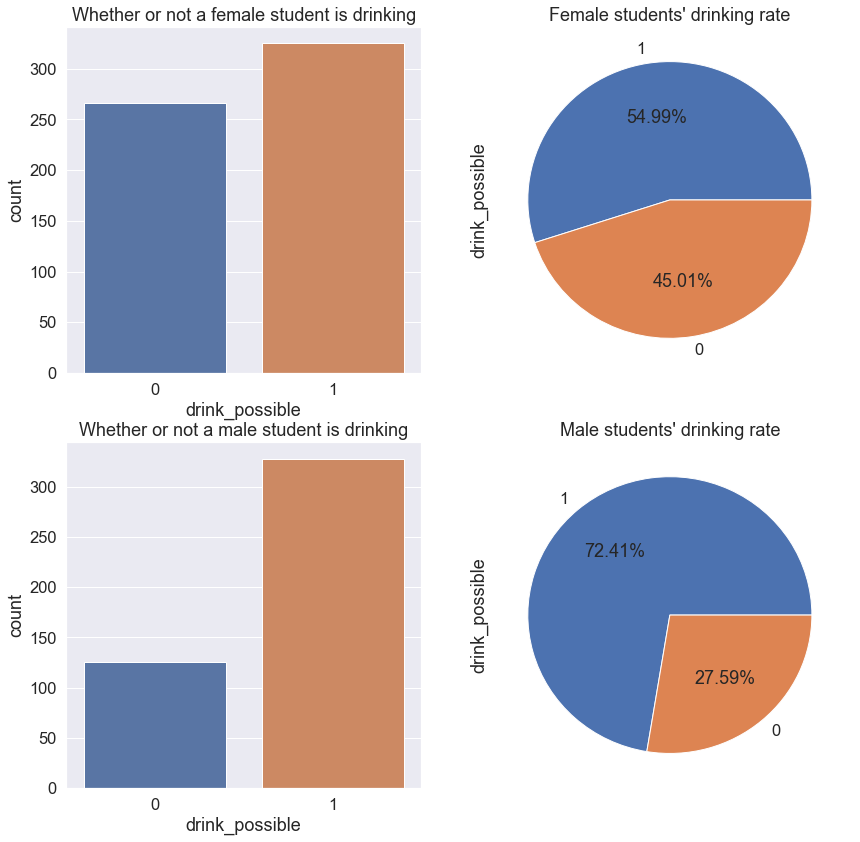

```python
x, ax = plt.subplots(2, 2, figsize=(14, 14))
# 다차원이므로 행과 열의 인덱스를 따로 따로 잡아준다.
sns.countplot(data=fe_drink, x = "drink_possible", ax=ax[0][0])
# 카운트플랏을 사용해서 해당 데이터의 0과 1의 갯수를 카운트 후 막대그래프로 시각화
fe_drink["drink_possible"].value_counts().plot.pie(autopct="%1.2f%%", ax=ax[0][1])
# 파이그래프를 활용해서 0과1의 값을 카운트한 후 비율로서 시각화
sns.countplot(data=ma_drink, x = "drink_possible", ax=ax[1][0])
ma_drink["drink_possible"].value_counts().plot.pie(autopct="%1.2f%%", ax=ax[1][1])
ax[0][0].set_title("Whether or not a female student is drinking")
ax[0][1].set_title("Female students' drinking rate")
ax[1][0].set_title("Whether or not a male student is drinking")
ax[1][1].set_title("Male students' drinking rate")
# 1 = 음주, 0 = 비음주
plt.show()
```

## 인사이트

##### 남학생과 여학생 중 음주하는 학생의 수는 서로 비슷한 정도

##### 하지만 음주를 하는 학생수의 비율은 남학생이 월등히 높음

##### 남학생이 여학생보다 음주를 할 확률이 높다.

```python
raw_data
```

|  | sex | age | address | famsize | Pstatus | Medu | Fedu | Mjob | Fjob | guardian | ... | internet | romantic | famrel | freetime | goout | Dalc | Walc | health | absences | drink_possible |
| --- | --- | --- | --- | --- | --- | --- | --- | --- | --- | --- | --- | --- | --- | --- | --- | --- | --- | --- | --- | --- | --- |
| 0 | F | 18 | U | GT3 | A | 4 | 4 | at_home | teacher | mother | ... | no | no | 4 | 3 | 4 | 1 | 1 | 3 | 4 | 0 |
| 1 | F | 17 | U | GT3 | T | 1 | 1 | at_home | other | father | ... | yes | no | 5 | 3 | 3 | 1 | 1 | 3 | 2 | 0 |
| 2 | F | 15 | U | LE3 | T | 1 | 1 | at_home | other | mother | ... | yes | no | 4 | 3 | 2 | 2 | 3 | 3 | 6 | 1 |
| 3 | F | 15 | U | GT3 | T | 4 | 2 | health | services | mother | ... | yes | yes | 3 | 2 | 2 | 1 | 1 | 5 | 0 | 0 |
| 4 | F | 16 | U | GT3 | T | 3 | 3 | other | other | father | ... | no | no | 4 | 3 | 2 | 1 | 2 | 5 | 0 | 1 |
| 5 | M | 16 | U | LE3 | T | 4 | 3 | services | other | mother | ... | yes | no | 5 | 4 | 2 | 1 | 2 | 5 | 6 | 1 |
| 6 | M | 16 | U | LE3 | T | 2 | 2 | other | other | mother | ... | yes | no | 4 | 4 | 4 | 1 | 1 | 3 | 0 | 0 |
| 7 | F | 17 | U | GT3 | A | 4 | 4 | other | teacher | mother | ... | no | no | 4 | 1 | 4 | 1 | 1 | 1 | 2 | 0 |
| 8 | M | 15 | U | LE3 | A | 3 | 2 | services | other | mother | ... | yes | no | 4 | 2 | 2 | 1 | 1 | 1 | 0 | 0 |
| 9 | M | 15 | U | GT3 | T | 3 | 4 | other | other | mother | ... | yes | no | 5 | 5 | 1 | 1 | 1 | 5 | 0 | 0 |
| 10 | F | 15 | U | GT3 | T | 4 | 4 | teacher | health | mother | ... | yes | no | 3 | 3 | 3 | 1 | 2 | 2 | 2 | 1 |
| 11 | F | 15 | U | GT3 | T | 2 | 1 | services | other | father | ... | yes | no | 5 | 2 | 2 | 1 | 1 | 4 | 0 | 0 |
| 12 | M | 15 | U | LE3 | T | 4 | 4 | health | services | father | ... | yes | no | 4 | 3 | 3 | 1 | 3 | 5 | 0 | 1 |
| 13 | M | 15 | U | GT3 | T | 4 | 3 | teacher | other | mother | ... | yes | no | 5 | 4 | 3 | 1 | 2 | 3 | 0 | 1 |
| 14 | M | 15 | U | GT3 | A | 2 | 2 | other | other | other | ... | yes | yes | 4 | 5 | 2 | 1 | 1 | 3 | 0 | 0 |
| 15 | F | 16 | U | GT3 | T | 4 | 4 | health | other | mother | ... | yes | no | 4 | 4 | 4 | 1 | 2 | 2 | 6 | 1 |
| 16 | F | 16 | U | GT3 | T | 4 | 4 | services | services | mother | ... | yes | no | 3 | 2 | 3 | 1 | 2 | 2 | 10 | 1 |
| 17 | F | 16 | U | GT3 | T | 3 | 3 | other | other | mother | ... | no | no | 5 | 3 | 2 | 1 | 1 | 4 | 2 | 0 |
| 18 | M | 17 | U | GT3 | T | 3 | 2 | services | services | mother | ... | yes | no | 5 | 5 | 5 | 2 | 4 | 5 | 2 | 1 |
| 19 | M | 16 | U | LE3 | T | 4 | 3 | health | other | father | ... | yes | no | 3 | 1 | 3 | 1 | 3 | 5 | 6 | 1 |
| 20 | M | 15 | U | GT3 | T | 4 | 3 | teacher | other | mother | ... | yes | no | 4 | 4 | 1 | 1 | 1 | 1 | 0 | 0 |
| 21 | M | 15 | U | GT3 | T | 4 | 4 | health | health | father | ... | yes | no | 5 | 4 | 2 | 1 | 1 | 5 | 0 | 0 |
| 22 | M | 16 | U | LE3 | T | 4 | 2 | teacher | other | mother | ... | yes | no | 4 | 5 | 1 | 1 | 3 | 5 | 0 | 1 |
| 23 | M | 16 | U | LE3 | T | 2 | 2 | other | other | mother | ... | yes | no | 5 | 4 | 4 | 2 | 4 | 5 | 2 | 1 |
| 24 | F | 15 | R | GT3 | T | 2 | 4 | services | health | mother | ... | yes | no | 4 | 3 | 2 | 1 | 1 | 5 | 2 | 0 |
| 25 | F | 16 | U | GT3 | T | 2 | 2 | services | services | mother | ... | yes | no | 1 | 2 | 2 | 1 | 3 | 5 | 6 | 1 |
| 26 | M | 15 | U | GT3 | T | 2 | 2 | other | other | mother | ... | yes | no | 4 | 2 | 2 | 1 | 2 | 5 | 8 | 1 |
| 27 | M | 15 | U | GT3 | T | 4 | 2 | health | services | mother | ... | yes | no | 2 | 2 | 4 | 2 | 4 | 1 | 0 | 1 |
| 28 | M | 16 | U | LE3 | A | 3 | 4 | services | other | mother | ... | yes | no | 5 | 3 | 3 | 1 | 1 | 5 | 2 | 0 |
| 29 | M | 16 | U | GT3 | T | 4 | 4 | teacher | teacher | mother | ... | yes | yes | 4 | 4 | 5 | 5 | 5 | 5 | 4 | 1 |
| ... | ... | ... | ... | ... | ... | ... | ... | ... | ... | ... | ... | ... | ... | ... | ... | ... | ... | ... | ... | ... | ... |
| 1014 | M | 18 | R | GT3 | T | 1 | 3 | at_home | other | mother | ... | no | no | 3 | 3 | 4 | 2 | 4 | 3 | 4 | 1 |
| 1015 | M | 18 | U | LE3 | T | 4 | 4 | teacher | services | mother | ... | yes | yes | 4 | 2 | 2 | 2 | 2 | 5 | 0 | 1 |
| 1016 | F | 17 | R | GT3 | T | 1 | 1 | other | services | mother | ... | yes | yes | 5 | 2 | 1 | 1 | 2 | 1 | 0 | 1 |
| 1017 | F | 18 | U | GT3 | T | 2 | 3 | at_home | services | father | ... | yes | yes | 5 | 2 | 3 | 1 | 2 | 4 | 0 | 1 |
| 1018 | F | 18 | R | GT3 | T | 4 | 4 | other | teacher | father | ... | yes | yes | 3 | 2 | 2 | 4 | 2 | 5 | 10 | 1 |
| 1019 | F | 19 | U | LE3 | T | 3 | 2 | services | services | other | ... | no | yes | 3 | 2 | 2 | 1 | 1 | 3 | 4 | 0 |
| 1020 | M | 18 | R | LE3 | T | 1 | 2 | at_home | services | father | ... | yes | yes | 4 | 3 | 3 | 2 | 3 | 3 | 3 | 1 |
| 1021 | F | 17 | U | GT3 | T | 2 | 2 | other | at_home | mother | ... | no | yes | 3 | 4 | 3 | 1 | 1 | 3 | 8 | 0 |
| 1022 | F | 17 | R | GT3 | T | 1 | 2 | other | other | mother | ... | yes | no | 3 | 5 | 5 | 1 | 3 | 1 | 14 | 1 |
| 1023 | F | 18 | R | LE3 | T | 4 | 4 | other | other | mother | ... | yes | no | 5 | 4 | 4 | 1 | 1 | 1 | 0 | 0 |
| 1024 | F | 18 | R | GT3 | T | 1 | 1 | other | other | mother | ... | yes | no | 4 | 3 | 2 | 1 | 2 | 4 | 2 | 1 |
| 1025 | F | 20 | U | GT3 | T | 4 | 2 | health | other | other | ... | yes | yes | 5 | 4 | 3 | 1 | 1 | 3 | 4 | 0 |
| 1026 | F | 18 | R | LE3 | T | 4 | 4 | teacher | services | mother | ... | yes | no | 5 | 4 | 3 | 3 | 4 | 2 | 4 | 1 |
| 1027 | F | 18 | U | GT3 | T | 3 | 3 | other | other | mother | ... | yes | yes | 4 | 1 | 3 | 1 | 2 | 1 | 0 | 1 |
| 1028 | F | 17 | R | GT3 | T | 3 | 1 | at_home | other | mother | ... | yes | no | 4 | 5 | 4 | 2 | 3 | 1 | 17 | 1 |
| 1029 | M | 18 | U | GT3 | T | 4 | 4 | teacher | teacher | father | ... | yes | no | 3 | 2 | 4 | 1 | 4 | 2 | 4 | 1 |
| 1030 | M | 18 | R | GT3 | T | 2 | 1 | other | other | mother | ... | yes | yes | 4 | 4 | 3 | 1 | 3 | 5 | 5 | 1 |
| 1031 | M | 17 | U | GT3 | T | 2 | 3 | other | services | father | ... | yes | no | 4 | 4 | 3 | 1 | 1 | 3 | 2 | 0 |
| 1032 | M | 19 | R | GT3 | T | 1 | 1 | other | services | mother | ... | no | no | 4 | 3 | 2 | 1 | 3 | 5 | 0 | 1 |
| 1033 | M | 18 | R | GT3 | T | 4 | 2 | other | other | father | ... | no | no | 5 | 4 | 3 | 4 | 3 | 3 | 14 | 1 |
| 1034 | F | 18 | R | GT3 | T | 2 | 2 | at_home | other | mother | ... | no | no | 5 | 3 | 3 | 1 | 3 | 4 | 2 | 1 |
| 1035 | F | 18 | R | GT3 | T | 4 | 4 | teacher | at_home | mother | ... | yes | yes | 4 | 4 | 3 | 2 | 2 | 5 | 7 | 1 |
| 1036 | F | 19 | R | GT3 | T | 2 | 3 | services | other | mother | ... | yes | no | 5 | 4 | 2 | 1 | 2 | 5 | 0 | 1 |
| 1037 | F | 18 | U | LE3 | T | 3 | 1 | teacher | services | mother | ... | yes | no | 4 | 3 | 4 | 1 | 1 | 1 | 0 | 0 |
| 1038 | F | 18 | U | GT3 | T | 1 | 1 | other | other | mother | ... | no | no | 1 | 1 | 1 | 1 | 1 | 5 | 0 | 0 |
| 1039 | M | 20 | U | LE3 | A | 2 | 2 | services | services | other | ... | no | no | 5 | 5 | 4 | 4 | 5 | 4 | 11 | 1 |
| 1040 | M | 17 | U | LE3 | T | 3 | 1 | services | services | mother | ... | yes | no | 2 | 4 | 5 | 3 | 4 | 2 | 3 | 1 |
| 1041 | M | 21 | R | GT3 | T | 1 | 1 | other | other | other | ... | no | no | 5 | 5 | 3 | 3 | 3 | 3 | 3 | 1 |
| 1042 | M | 18 | R | LE3 | T | 3 | 2 | services | other | mother | ... | yes | no | 4 | 4 | 1 | 3 | 4 | 5 | 0 | 1 |
| 1043 | M | 19 | U | LE3 | T | 1 | 1 | other | at_home | father | ... | yes | no | 3 | 2 | 3 | 3 | 3 | 5 | 5 | 1 |

1044 rows × 27 columns

```python
Pstatus_sex_drink = raw_data.loc[0:, ["Pstatus", "sex", "drink_possible"]]
# loc는 , 를 기준으로 앞이 행(row)의 영역 뒤는 열(컬럼)의 영역이다.
Pstatus_sex_drink.head()
# 부모님과의 동거 여부가 음주에 영향을 미치는지 확인하기 위한 데이터프레임 처리
```

|  | Pstatus | sex | drink_possible |
| --- | --- | --- | --- |
| 0 | A | F | 0 |
| 1 | T | F | 0 |
| 2 | T | F | 1 |
| 3 | T | F | 0 |
| 4 | T | F | 1 |

```python
t_sex_drink = Pstatus_sex_drink[Pstatus_sex_drink["Pstatus"] == "T"]
t_sex_drink.head()
# 부모님의 동거여부가 음주에 영향을 미치는지를 확인하기 위해 같이 사는 조건으로 값을 출력
```

|  | Pstatus | sex | drink_possible |
| --- | --- | --- | --- |
| 1 | T | F | 0 |
| 2 | T | F | 1 |
| 3 | T | F | 0 |
| 4 | T | F | 1 |
| 5 | T | M | 1 |

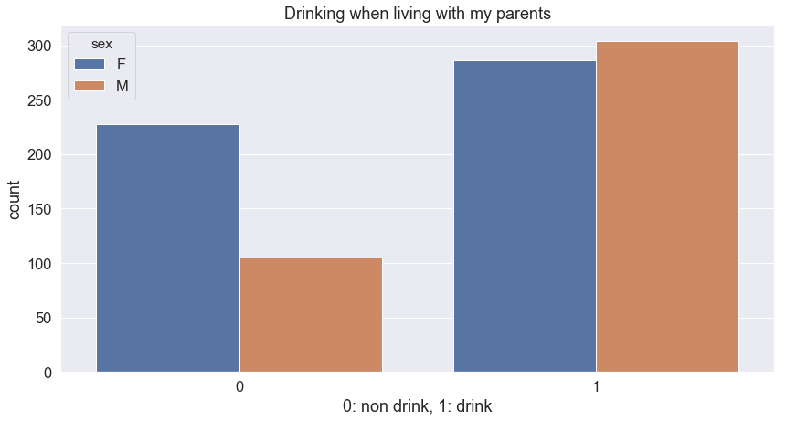

```python
x, ax = plt.subplots(1, 1, figsize=(14, 7))
sns.countplot(data=t_sex_drink, x="drink_possible", hue="sex")
# # 부모님과 같이 살때 음주여부를 출력한다. hue="sex"는 sex컬럼의 값으로 분리시켜 countplot을 해준다.
plt.title("Drinking when living with my parents")
plt.xlabel("0: non drink, 1: drink")
plt.show()
```

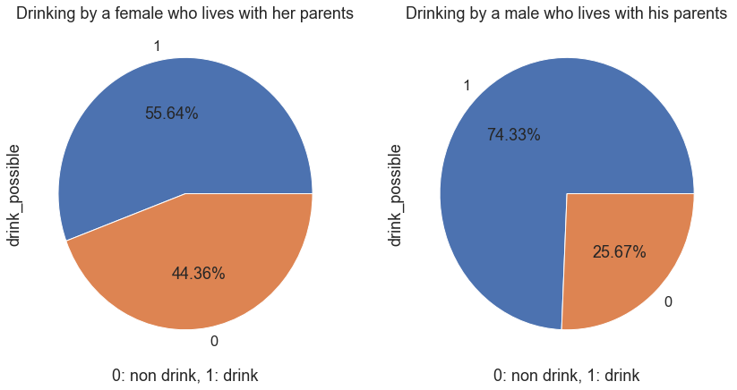

```python
t_f_drink = t_sex_drink[t_sex_drink["sex"] == "F"].drink_possible.to_frame()
t_m_drink = t_sex_drink[t_sex_drink["sex"] == "M"].drink_possible.to_frame()
# 부모님과 같이 사는 학생의 성별에 따른 음주여부 데이터 프레임 생성

x, ax = plt.subplots(1, 2, figsize=(14, 7))
t_f_drink["drink_possible"].value_counts().plot.pie(autopct="%1.2f%%", ax=ax[0])
t_m_drink["drink_possible"].value_counts().plot.pie(autopct="%1.2f%%", ax=ax[1])
ax[0].set_title("Drinking by a female who lives with her parents")
ax[1].set_title("Drinking by a male who lives with his parents")
ax[0].set_xlabel("0: non drink, 1: drink")
ax[1].set_xlabel("0: non drink, 1: drink")
plt.show()
```

## 인사이트

##### 부모님과 함께 거주하는 학생 중 음주를 하는 학생의 수는 남학생과 여학생이 비슷하다.(절대적 수치상)

##### 부모님과 함께 거주하는 학생 중 음주를 하지 않는 학생은 여학생이 월등하게 높다.(절대적 수치상)

##### 총 인원수가 다르기 때문에 비율로 따져야한다.

##### 부모님과 동거하는 여학생의 음주 비율은 55.64% 이고 남학생의 음주비율은 74.33% 이다.

##### 부모님과 동거하며 음주하는 절대적 수치는 남학생과 여학생이 비슷하지만 비율로 봤을때는 남학생이 훨씬 높다.

```python
a_sex_drink = Pstatus_sex_drink[Pstatus_sex_drink["Pstatus"] == "A"]
a_sex_drink.head()
# 부모님과 함께 살지 않는 데이터
# 비동거는 121개 row
```

|  | Pstatus | sex | drink_possible |
| --- | --- | --- | --- |
| 0 | A | F | 0 |
| 7 | A | F | 0 |
| 8 | A | M | 0 |
| 14 | A | M | 0 |
| 28 | A | M | 0 |

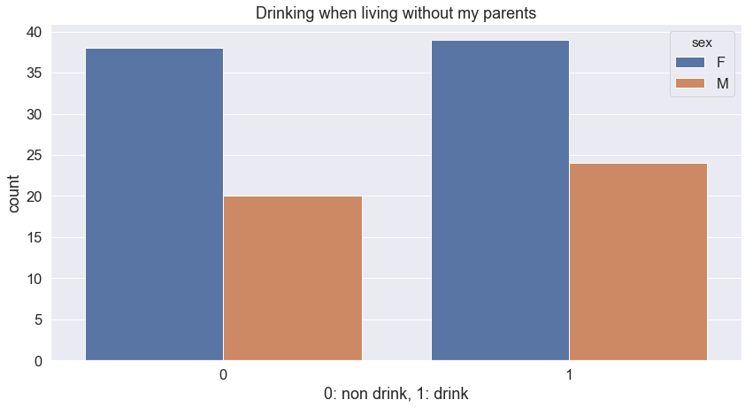

```python
x, ax = plt.subplots(1, 1, figsize=(14, 7))
sns.countplot(data=a_sex_drink, x="drink_possible", hue="sex")
plt.title("Drinking when living without my parents")
plt.xlabel("0: non drink, 1: drink")
plt.show()
```

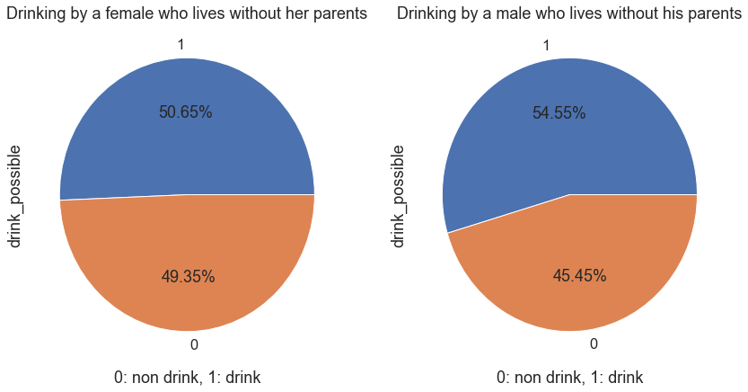

```python
a_f_drink = a_sex_drink[a_sex_drink["sex"] == "F"].drink_possible.to_frame()
a_m_drink = a_sex_drink[a_sex_drink["sex"] == "M"].drink_possible.to_frame()
# 부모님과 따로 사는 학생의 성별에 따른 음주여부 데이터 프레임 생성

x, ax = plt.subplots(1, 2, figsize=(14, 7))
a_f_drink["drink_possible"].value_counts().plot.pie(autopct="%1.2f%%", ax=ax[0])
a_m_drink["drink_possible"].value_counts().plot.pie(autopct="%1.2f%%", ax=ax[1])
ax[0].set_title("Drinking by a female who lives without her parents")
ax[1].set_title("Drinking by a male who lives without his parents")
ax[0].set_xlabel("0: non drink, 1: drink")
ax[1].set_xlabel("0: non drink, 1: drink")
plt.show()
```

## 인사이트

##### 남학생과 여학생의 총 인원수가 다르기 때문에 비율로 따져야한다.

##### 부모님과 동거하지 않는 여학생의 음주 비율은 50.65% 이고 남학생의 음주비율은 54.55% 이다.

##### 부모님과 동거하지 않는 학생 중 남학생이 음주를 하고 있는 비율이 더 높다.

```python
raw_data["address"].value_counts()
# 표본의 거주지는 수치 차이가 크기 때문에 비율로 비교하는게 효과적
```

```
U    759
R    285
Name: address, dtype: int64
```

```python
ad_drink = raw_data[["address", "drink_possible"]]
ad_u_drink = ad_drink[ad_drink["address"] == "U"]
ad_r_drink = ad_drink[ad_drink["address"] == "R"]
# 거주지를 기준으로 음주를 하는지 안하는지 확인하기 위한 처리
```

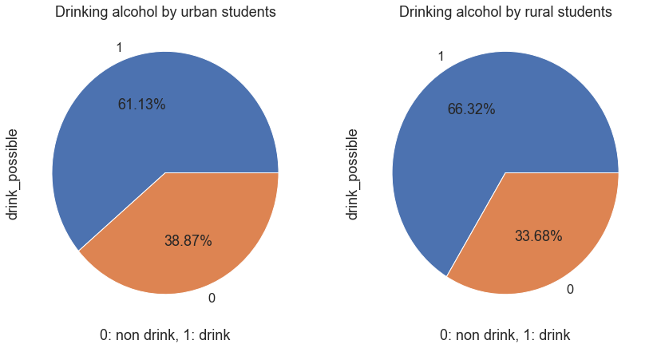

```python
x, ax = plt.subplots(1, 2, figsize=(14, 7))
ad_u_drink["drink_possible"].value_counts().plot.pie(autopct="%1.2f%%", ax=ax[0])
ad_r_drink["drink_possible"].value_counts().plot.pie(autopct="%1.2f%%", ax=ax[1])
ax[0].set_title("Drinking alcohol by urban students")
ax[1].set_title("Drinking alcohol by rural students")
ax[0].set_xlabel("0: non drink, 1: drink")
ax[1].set_xlabel("0: non drink, 1: drink")
plt.show()
```

## 인사이트

##### 시골에 거주하는 학생이 도시에 거주하는 학생보다 음주를 하는 비율이 약간 높다.(약 5%차이)

```python
raw_data
```

|  | sex | age | address | famsize | Pstatus | Medu | Fedu | Mjob | Fjob | guardian | ... | internet | romantic | famrel | freetime | goout | Dalc | Walc | health | absences | drink_possible |
| --- | --- | --- | --- | --- | --- | --- | --- | --- | --- | --- | --- | --- | --- | --- | --- | --- | --- | --- | --- | --- | --- |
| 0 | F | 18 | U | GT3 | A | 4 | 4 | at_home | teacher | mother | ... | no | no | 4 | 3 | 4 | 1 | 1 | 3 | 4 | 0 |
| 1 | F | 17 | U | GT3 | T | 1 | 1 | at_home | other | father | ... | yes | no | 5 | 3 | 3 | 1 | 1 | 3 | 2 | 0 |
| 2 | F | 15 | U | LE3 | T | 1 | 1 | at_home | other | mother | ... | yes | no | 4 | 3 | 2 | 2 | 3 | 3 | 6 | 1 |
| 3 | F | 15 | U | GT3 | T | 4 | 2 | health | services | mother | ... | yes | yes | 3 | 2 | 2 | 1 | 1 | 5 | 0 | 0 |
| 4 | F | 16 | U | GT3 | T | 3 | 3 | other | other | father | ... | no | no | 4 | 3 | 2 | 1 | 2 | 5 | 0 | 1 |
| 5 | M | 16 | U | LE3 | T | 4 | 3 | services | other | mother | ... | yes | no | 5 | 4 | 2 | 1 | 2 | 5 | 6 | 1 |
| 6 | M | 16 | U | LE3 | T | 2 | 2 | other | other | mother | ... | yes | no | 4 | 4 | 4 | 1 | 1 | 3 | 0 | 0 |
| 7 | F | 17 | U | GT3 | A | 4 | 4 | other | teacher | mother | ... | no | no | 4 | 1 | 4 | 1 | 1 | 1 | 2 | 0 |
| 8 | M | 15 | U | LE3 | A | 3 | 2 | services | other | mother | ... | yes | no | 4 | 2 | 2 | 1 | 1 | 1 | 0 | 0 |
| 9 | M | 15 | U | GT3 | T | 3 | 4 | other | other | mother | ... | yes | no | 5 | 5 | 1 | 1 | 1 | 5 | 0 | 0 |
| 10 | F | 15 | U | GT3 | T | 4 | 4 | teacher | health | mother | ... | yes | no | 3 | 3 | 3 | 1 | 2 | 2 | 2 | 1 |
| 11 | F | 15 | U | GT3 | T | 2 | 1 | services | other | father | ... | yes | no | 5 | 2 | 2 | 1 | 1 | 4 | 0 | 0 |
| 12 | M | 15 | U | LE3 | T | 4 | 4 | health | services | father | ... | yes | no | 4 | 3 | 3 | 1 | 3 | 5 | 0 | 1 |
| 13 | M | 15 | U | GT3 | T | 4 | 3 | teacher | other | mother | ... | yes | no | 5 | 4 | 3 | 1 | 2 | 3 | 0 | 1 |
| 14 | M | 15 | U | GT3 | A | 2 | 2 | other | other | other | ... | yes | yes | 4 | 5 | 2 | 1 | 1 | 3 | 0 | 0 |
| 15 | F | 16 | U | GT3 | T | 4 | 4 | health | other | mother | ... | yes | no | 4 | 4 | 4 | 1 | 2 | 2 | 6 | 1 |
| 16 | F | 16 | U | GT3 | T | 4 | 4 | services | services | mother | ... | yes | no | 3 | 2 | 3 | 1 | 2 | 2 | 10 | 1 |
| 17 | F | 16 | U | GT3 | T | 3 | 3 | other | other | mother | ... | no | no | 5 | 3 | 2 | 1 | 1 | 4 | 2 | 0 |
| 18 | M | 17 | U | GT3 | T | 3 | 2 | services | services | mother | ... | yes | no | 5 | 5 | 5 | 2 | 4 | 5 | 2 | 1 |
| 19 | M | 16 | U | LE3 | T | 4 | 3 | health | other | father | ... | yes | no | 3 | 1 | 3 | 1 | 3 | 5 | 6 | 1 |
| 20 | M | 15 | U | GT3 | T | 4 | 3 | teacher | other | mother | ... | yes | no | 4 | 4 | 1 | 1 | 1 | 1 | 0 | 0 |
| 21 | M | 15 | U | GT3 | T | 4 | 4 | health | health | father | ... | yes | no | 5 | 4 | 2 | 1 | 1 | 5 | 0 | 0 |
| 22 | M | 16 | U | LE3 | T | 4 | 2 | teacher | other | mother | ... | yes | no | 4 | 5 | 1 | 1 | 3 | 5 | 0 | 1 |
| 23 | M | 16 | U | LE3 | T | 2 | 2 | other | other | mother | ... | yes | no | 5 | 4 | 4 | 2 | 4 | 5 | 2 | 1 |
| 24 | F | 15 | R | GT3 | T | 2 | 4 | services | health | mother | ... | yes | no | 4 | 3 | 2 | 1 | 1 | 5 | 2 | 0 |
| 25 | F | 16 | U | GT3 | T | 2 | 2 | services | services | mother | ... | yes | no | 1 | 2 | 2 | 1 | 3 | 5 | 6 | 1 |
| 26 | M | 15 | U | GT3 | T | 2 | 2 | other | other | mother | ... | yes | no | 4 | 2 | 2 | 1 | 2 | 5 | 8 | 1 |
| 27 | M | 15 | U | GT3 | T | 4 | 2 | health | services | mother | ... | yes | no | 2 | 2 | 4 | 2 | 4 | 1 | 0 | 1 |
| 28 | M | 16 | U | LE3 | A | 3 | 4 | services | other | mother | ... | yes | no | 5 | 3 | 3 | 1 | 1 | 5 | 2 | 0 |
| 29 | M | 16 | U | GT3 | T | 4 | 4 | teacher | teacher | mother | ... | yes | yes | 4 | 4 | 5 | 5 | 5 | 5 | 4 | 1 |
| ... | ... | ... | ... | ... | ... | ... | ... | ... | ... | ... | ... | ... | ... | ... | ... | ... | ... | ... | ... | ... | ... |
| 1014 | M | 18 | R | GT3 | T | 1 | 3 | at_home | other | mother | ... | no | no | 3 | 3 | 4 | 2 | 4 | 3 | 4 | 1 |
| 1015 | M | 18 | U | LE3 | T | 4 | 4 | teacher | services | mother | ... | yes | yes | 4 | 2 | 2 | 2 | 2 | 5 | 0 | 1 |
| 1016 | F | 17 | R | GT3 | T | 1 | 1 | other | services | mother | ... | yes | yes | 5 | 2 | 1 | 1 | 2 | 1 | 0 | 1 |
| 1017 | F | 18 | U | GT3 | T | 2 | 3 | at_home | services | father | ... | yes | yes | 5 | 2 | 3 | 1 | 2 | 4 | 0 | 1 |
| 1018 | F | 18 | R | GT3 | T | 4 | 4 | other | teacher | father | ... | yes | yes | 3 | 2 | 2 | 4 | 2 | 5 | 10 | 1 |
| 1019 | F | 19 | U | LE3 | T | 3 | 2 | services | services | other | ... | no | yes | 3 | 2 | 2 | 1 | 1 | 3 | 4 | 0 |
| 1020 | M | 18 | R | LE3 | T | 1 | 2 | at_home | services | father | ... | yes | yes | 4 | 3 | 3 | 2 | 3 | 3 | 3 | 1 |
| 1021 | F | 17 | U | GT3 | T | 2 | 2 | other | at_home | mother | ... | no | yes | 3 | 4 | 3 | 1 | 1 | 3 | 8 | 0 |
| 1022 | F | 17 | R | GT3 | T | 1 | 2 | other | other | mother | ... | yes | no | 3 | 5 | 5 | 1 | 3 | 1 | 14 | 1 |
| 1023 | F | 18 | R | LE3 | T | 4 | 4 | other | other | mother | ... | yes | no | 5 | 4 | 4 | 1 | 1 | 1 | 0 | 0 |
| 1024 | F | 18 | R | GT3 | T | 1 | 1 | other | other | mother | ... | yes | no | 4 | 3 | 2 | 1 | 2 | 4 | 2 | 1 |
| 1025 | F | 20 | U | GT3 | T | 4 | 2 | health | other | other | ... | yes | yes | 5 | 4 | 3 | 1 | 1 | 3 | 4 | 0 |
| 1026 | F | 18 | R | LE3 | T | 4 | 4 | teacher | services | mother | ... | yes | no | 5 | 4 | 3 | 3 | 4 | 2 | 4 | 1 |
| 1027 | F | 18 | U | GT3 | T | 3 | 3 | other | other | mother | ... | yes | yes | 4 | 1 | 3 | 1 | 2 | 1 | 0 | 1 |
| 1028 | F | 17 | R | GT3 | T | 3 | 1 | at_home | other | mother | ... | yes | no | 4 | 5 | 4 | 2 | 3 | 1 | 17 | 1 |
| 1029 | M | 18 | U | GT3 | T | 4 | 4 | teacher | teacher | father | ... | yes | no | 3 | 2 | 4 | 1 | 4 | 2 | 4 | 1 |
| 1030 | M | 18 | R | GT3 | T | 2 | 1 | other | other | mother | ... | yes | yes | 4 | 4 | 3 | 1 | 3 | 5 | 5 | 1 |
| 1031 | M | 17 | U | GT3 | T | 2 | 3 | other | services | father | ... | yes | no | 4 | 4 | 3 | 1 | 1 | 3 | 2 | 0 |
| 1032 | M | 19 | R | GT3 | T | 1 | 1 | other | services | mother | ... | no | no | 4 | 3 | 2 | 1 | 3 | 5 | 0 | 1 |
| 1033 | M | 18 | R | GT3 | T | 4 | 2 | other | other | father | ... | no | no | 5 | 4 | 3 | 4 | 3 | 3 | 14 | 1 |
| 1034 | F | 18 | R | GT3 | T | 2 | 2 | at_home | other | mother | ... | no | no | 5 | 3 | 3 | 1 | 3 | 4 | 2 | 1 |
| 1035 | F | 18 | R | GT3 | T | 4 | 4 | teacher | at_home | mother | ... | yes | yes | 4 | 4 | 3 | 2 | 2 | 5 | 7 | 1 |
| 1036 | F | 19 | R | GT3 | T | 2 | 3 | services | other | mother | ... | yes | no | 5 | 4 | 2 | 1 | 2 | 5 | 0 | 1 |
| 1037 | F | 18 | U | LE3 | T | 3 | 1 | teacher | services | mother | ... | yes | no | 4 | 3 | 4 | 1 | 1 | 1 | 0 | 0 |
| 1038 | F | 18 | U | GT3 | T | 1 | 1 | other | other | mother | ... | no | no | 1 | 1 | 1 | 1 | 1 | 5 | 0 | 0 |
| 1039 | M | 20 | U | LE3 | A | 2 | 2 | services | services | other | ... | no | no | 5 | 5 | 4 | 4 | 5 | 4 | 11 | 1 |
| 1040 | M | 17 | U | LE3 | T | 3 | 1 | services | services | mother | ... | yes | no | 2 | 4 | 5 | 3 | 4 | 2 | 3 | 1 |
| 1041 | M | 21 | R | GT3 | T | 1 | 1 | other | other | other | ... | no | no | 5 | 5 | 3 | 3 | 3 | 3 | 3 | 1 |
| 1042 | M | 18 | R | LE3 | T | 3 | 2 | services | other | mother | ... | yes | no | 4 | 4 | 1 | 3 | 4 | 5 | 0 | 1 |
| 1043 | M | 19 | U | LE3 | T | 1 | 1 | other | at_home | father | ... | yes | no | 3 | 2 | 3 | 3 | 3 | 5 | 5 | 1 |

1044 rows × 27 columns

## 가설 검증을 위한 머신러닝 모델 채택 과정

## 가설 : 부모의 영향에 따라 자녀가 음주를 할지 안할지를 검정

```python
raw_data.columns
# 머신러닝에 사용할 독립변수 뽑기
# 부모의 영향이 독립변수로 작용한다.
```

```
Index(['sex', 'age', 'address', 'famsize', 'Pstatus', 'Medu', 'Fedu', 'Mjob',
       'Fjob', 'guardian', 'traveltime', 'studytime', 'failures', 'famsup',
       'paid', 'activities', 'higher', 'internet', 'romantic', 'famrel',
       'freetime', 'goout', 'Dalc', 'Walc', 'health', 'absences',
       'drink_possible'],
      dtype='object')
```

```python
# 컬럼명이 길어서 간결하게 변경해주기
raw_data = raw_data.rename({"drink_possible":"dp"}, axis="columns")
raw_data
```

|  | sex | age | address | famsize | Pstatus | Medu | Fedu | Mjob | Fjob | guardian | ... | internet | romantic | famrel | freetime | goout | Dalc | Walc | health | absences | dp |
| --- | --- | --- | --- | --- | --- | --- | --- | --- | --- | --- | --- | --- | --- | --- | --- | --- | --- | --- | --- | --- | --- |
| 0 | F | 18 | U | GT3 | A | 4 | 4 | at_home | teacher | mother | ... | no | no | 4 | 3 | 4 | 1 | 1 | 3 | 4 | 0 |
| 1 | F | 17 | U | GT3 | T | 1 | 1 | at_home | other | father | ... | yes | no | 5 | 3 | 3 | 1 | 1 | 3 | 2 | 0 |
| 2 | F | 15 | U | LE3 | T | 1 | 1 | at_home | other | mother | ... | yes | no | 4 | 3 | 2 | 2 | 3 | 3 | 6 | 1 |
| 3 | F | 15 | U | GT3 | T | 4 | 2 | health | services | mother | ... | yes | yes | 3 | 2 | 2 | 1 | 1 | 5 | 0 | 0 |
| 4 | F | 16 | U | GT3 | T | 3 | 3 | other | other | father | ... | no | no | 4 | 3 | 2 | 1 | 2 | 5 | 0 | 1 |
| 5 | M | 16 | U | LE3 | T | 4 | 3 | services | other | mother | ... | yes | no | 5 | 4 | 2 | 1 | 2 | 5 | 6 | 1 |
| 6 | M | 16 | U | LE3 | T | 2 | 2 | other | other | mother | ... | yes | no | 4 | 4 | 4 | 1 | 1 | 3 | 0 | 0 |
| 7 | F | 17 | U | GT3 | A | 4 | 4 | other | teacher | mother | ... | no | no | 4 | 1 | 4 | 1 | 1 | 1 | 2 | 0 |
| 8 | M | 15 | U | LE3 | A | 3 | 2 | services | other | mother | ... | yes | no | 4 | 2 | 2 | 1 | 1 | 1 | 0 | 0 |
| 9 | M | 15 | U | GT3 | T | 3 | 4 | other | other | mother | ... | yes | no | 5 | 5 | 1 | 1 | 1 | 5 | 0 | 0 |
| 10 | F | 15 | U | GT3 | T | 4 | 4 | teacher | health | mother | ... | yes | no | 3 | 3 | 3 | 1 | 2 | 2 | 2 | 1 |
| 11 | F | 15 | U | GT3 | T | 2 | 1 | services | other | father | ... | yes | no | 5 | 2 | 2 | 1 | 1 | 4 | 0 | 0 |
| 12 | M | 15 | U | LE3 | T | 4 | 4 | health | services | father | ... | yes | no | 4 | 3 | 3 | 1 | 3 | 5 | 0 | 1 |
| 13 | M | 15 | U | GT3 | T | 4 | 3 | teacher | other | mother | ... | yes | no | 5 | 4 | 3 | 1 | 2 | 3 | 0 | 1 |
| 14 | M | 15 | U | GT3 | A | 2 | 2 | other | other | other | ... | yes | yes | 4 | 5 | 2 | 1 | 1 | 3 | 0 | 0 |
| 15 | F | 16 | U | GT3 | T | 4 | 4 | health | other | mother | ... | yes | no | 4 | 4 | 4 | 1 | 2 | 2 | 6 | 1 |
| 16 | F | 16 | U | GT3 | T | 4 | 4 | services | services | mother | ... | yes | no | 3 | 2 | 3 | 1 | 2 | 2 | 10 | 1 |
| 17 | F | 16 | U | GT3 | T | 3 | 3 | other | other | mother | ... | no | no | 5 | 3 | 2 | 1 | 1 | 4 | 2 | 0 |
| 18 | M | 17 | U | GT3 | T | 3 | 2 | services | services | mother | ... | yes | no | 5 | 5 | 5 | 2 | 4 | 5 | 2 | 1 |
| 19 | M | 16 | U | LE3 | T | 4 | 3 | health | other | father | ... | yes | no | 3 | 1 | 3 | 1 | 3 | 5 | 6 | 1 |
| 20 | M | 15 | U | GT3 | T | 4 | 3 | teacher | other | mother | ... | yes | no | 4 | 4 | 1 | 1 | 1 | 1 | 0 | 0 |
| 21 | M | 15 | U | GT3 | T | 4 | 4 | health | health | father | ... | yes | no | 5 | 4 | 2 | 1 | 1 | 5 | 0 | 0 |
| 22 | M | 16 | U | LE3 | T | 4 | 2 | teacher | other | mother | ... | yes | no | 4 | 5 | 1 | 1 | 3 | 5 | 0 | 1 |
| 23 | M | 16 | U | LE3 | T | 2 | 2 | other | other | mother | ... | yes | no | 5 | 4 | 4 | 2 | 4 | 5 | 2 | 1 |
| 24 | F | 15 | R | GT3 | T | 2 | 4 | services | health | mother | ... | yes | no | 4 | 3 | 2 | 1 | 1 | 5 | 2 | 0 |
| 25 | F | 16 | U | GT3 | T | 2 | 2 | services | services | mother | ... | yes | no | 1 | 2 | 2 | 1 | 3 | 5 | 6 | 1 |
| 26 | M | 15 | U | GT3 | T | 2 | 2 | other | other | mother | ... | yes | no | 4 | 2 | 2 | 1 | 2 | 5 | 8 | 1 |
| 27 | M | 15 | U | GT3 | T | 4 | 2 | health | services | mother | ... | yes | no | 2 | 2 | 4 | 2 | 4 | 1 | 0 | 1 |
| 28 | M | 16 | U | LE3 | A | 3 | 4 | services | other | mother | ... | yes | no | 5 | 3 | 3 | 1 | 1 | 5 | 2 | 0 |
| 29 | M | 16 | U | GT3 | T | 4 | 4 | teacher | teacher | mother | ... | yes | yes | 4 | 4 | 5 | 5 | 5 | 5 | 4 | 1 |
| ... | ... | ... | ... | ... | ... | ... | ... | ... | ... | ... | ... | ... | ... | ... | ... | ... | ... | ... | ... | ... | ... |
| 1014 | M | 18 | R | GT3 | T | 1 | 3 | at_home | other | mother | ... | no | no | 3 | 3 | 4 | 2 | 4 | 3 | 4 | 1 |
| 1015 | M | 18 | U | LE3 | T | 4 | 4 | teacher | services | mother | ... | yes | yes | 4 | 2 | 2 | 2 | 2 | 5 | 0 | 1 |
| 1016 | F | 17 | R | GT3 | T | 1 | 1 | other | services | mother | ... | yes | yes | 5 | 2 | 1 | 1 | 2 | 1 | 0 | 1 |
| 1017 | F | 18 | U | GT3 | T | 2 | 3 | at_home | services | father | ... | yes | yes | 5 | 2 | 3 | 1 | 2 | 4 | 0 | 1 |
| 1018 | F | 18 | R | GT3 | T | 4 | 4 | other | teacher | father | ... | yes | yes | 3 | 2 | 2 | 4 | 2 | 5 | 10 | 1 |
| 1019 | F | 19 | U | LE3 | T | 3 | 2 | services | services | other | ... | no | yes | 3 | 2 | 2 | 1 | 1 | 3 | 4 | 0 |
| 1020 | M | 18 | R | LE3 | T | 1 | 2 | at_home | services | father | ... | yes | yes | 4 | 3 | 3 | 2 | 3 | 3 | 3 | 1 |
| 1021 | F | 17 | U | GT3 | T | 2 | 2 | other | at_home | mother | ... | no | yes | 3 | 4 | 3 | 1 | 1 | 3 | 8 | 0 |
| 1022 | F | 17 | R | GT3 | T | 1 | 2 | other | other | mother | ... | yes | no | 3 | 5 | 5 | 1 | 3 | 1 | 14 | 1 |
| 1023 | F | 18 | R | LE3 | T | 4 | 4 | other | other | mother | ... | yes | no | 5 | 4 | 4 | 1 | 1 | 1 | 0 | 0 |
| 1024 | F | 18 | R | GT3 | T | 1 | 1 | other | other | mother | ... | yes | no | 4 | 3 | 2 | 1 | 2 | 4 | 2 | 1 |
| 1025 | F | 20 | U | GT3 | T | 4 | 2 | health | other | other | ... | yes | yes | 5 | 4 | 3 | 1 | 1 | 3 | 4 | 0 |
| 1026 | F | 18 | R | LE3 | T | 4 | 4 | teacher | services | mother | ... | yes | no | 5 | 4 | 3 | 3 | 4 | 2 | 4 | 1 |
| 1027 | F | 18 | U | GT3 | T | 3 | 3 | other | other | mother | ... | yes | yes | 4 | 1 | 3 | 1 | 2 | 1 | 0 | 1 |
| 1028 | F | 17 | R | GT3 | T | 3 | 1 | at_home | other | mother | ... | yes | no | 4 | 5 | 4 | 2 | 3 | 1 | 17 | 1 |
| 1029 | M | 18 | U | GT3 | T | 4 | 4 | teacher | teacher | father | ... | yes | no | 3 | 2 | 4 | 1 | 4 | 2 | 4 | 1 |
| 1030 | M | 18 | R | GT3 | T | 2 | 1 | other | other | mother | ... | yes | yes | 4 | 4 | 3 | 1 | 3 | 5 | 5 | 1 |
| 1031 | M | 17 | U | GT3 | T | 2 | 3 | other | services | father | ... | yes | no | 4 | 4 | 3 | 1 | 1 | 3 | 2 | 0 |
| 1032 | M | 19 | R | GT3 | T | 1 | 1 | other | services | mother | ... | no | no | 4 | 3 | 2 | 1 | 3 | 5 | 0 | 1 |
| 1033 | M | 18 | R | GT3 | T | 4 | 2 | other | other | father | ... | no | no | 5 | 4 | 3 | 4 | 3 | 3 | 14 | 1 |
| 1034 | F | 18 | R | GT3 | T | 2 | 2 | at_home | other | mother | ... | no | no | 5 | 3 | 3 | 1 | 3 | 4 | 2 | 1 |
| 1035 | F | 18 | R | GT3 | T | 4 | 4 | teacher | at_home | mother | ... | yes | yes | 4 | 4 | 3 | 2 | 2 | 5 | 7 | 1 |
| 1036 | F | 19 | R | GT3 | T | 2 | 3 | services | other | mother | ... | yes | no | 5 | 4 | 2 | 1 | 2 | 5 | 0 | 1 |
| 1037 | F | 18 | U | LE3 | T | 3 | 1 | teacher | services | mother | ... | yes | no | 4 | 3 | 4 | 1 | 1 | 1 | 0 | 0 |
| 1038 | F | 18 | U | GT3 | T | 1 | 1 | other | other | mother | ... | no | no | 1 | 1 | 1 | 1 | 1 | 5 | 0 | 0 |
| 1039 | M | 20 | U | LE3 | A | 2 | 2 | services | services | other | ... | no | no | 5 | 5 | 4 | 4 | 5 | 4 | 11 | 1 |
| 1040 | M | 17 | U | LE3 | T | 3 | 1 | services | services | mother | ... | yes | no | 2 | 4 | 5 | 3 | 4 | 2 | 3 | 1 |
| 1041 | M | 21 | R | GT3 | T | 1 | 1 | other | other | other | ... | no | no | 5 | 5 | 3 | 3 | 3 | 3 | 3 | 1 |
| 1042 | M | 18 | R | LE3 | T | 3 | 2 | services | other | mother | ... | yes | no | 4 | 4 | 1 | 3 | 4 | 5 | 0 | 1 |
| 1043 | M | 19 | U | LE3 | T | 1 | 1 | other | at_home | father | ... | yes | no | 3 | 2 | 3 | 3 | 3 | 5 | 5 | 1 |

1044 rows × 27 columns

```python
# 머신러닝에 사용할 컬럼들만 뽑아서 데이터프레임 만들기!
# 가설에 따라 부모의 영향이 있을 수 있는 컬럼들을 추출
ml_raw_data = raw_data[['sex', 'Pstatus', 'Medu', 'Fedu', 'Mjob', 'Fjob', 'guardian', 'famrel', 'dp']]
ml_raw_data.head()
```

|  | sex | Pstatus | Medu | Fedu | Mjob | Fjob | guardian | famrel | dp |
| --- | --- | --- | --- | --- | --- | --- | --- | --- | --- |
| 0 | F | A | 4 | 4 | at_home | teacher | mother | 4 | 0 |
| 1 | F | T | 1 | 1 | at_home | other | father | 5 | 0 |
| 2 | F | T | 1 | 1 | at_home | other | mother | 4 | 1 |
| 3 | F | T | 4 | 2 | health | services | mother | 3 | 0 |
| 4 | F | T | 3 | 3 | other | other | father | 4 | 1 |

```python
#데이터 분류 !!! 정답0, 1 의 비율을 맞춰주기 위해
# 표본 갯수 일치화.
# 5 : 5
# df.sort_values('컬럼명')  =>  해당 컬럼명의 값을 내림차순으로 정렬
temp0 = ml_raw_data.sort_values('dp')[0:391] # 정답이 0인 데이터
temp1 = ml_raw_data.sort_values('dp')[392:783] # 정답이 1인 데이터
temp0
```

|  | sex | Pstatus | Medu | Fedu | Mjob | Fjob | guardian | famrel | dp |
| --- | --- | --- | --- | --- | --- | --- | --- | --- | --- |
| 0 | F | A | 4 | 4 | at_home | teacher | mother | 4 | 0 |
| 582 | F | A | 1 | 1 | at_home | other | mother | 1 | 0 |
| 581 | F | A | 1 | 2 | at_home | other | mother | 4 | 0 |
| 572 | F | A | 3 | 2 | services | at_home | mother | 2 | 0 |
| 568 | M | T | 3 | 2 | at_home | services | mother | 3 | 0 |
| 562 | F | T | 2 | 2 | other | services | father | 5 | 0 |
| 559 | M | T | 1 | 0 | at_home | at_home | other | 4 | 0 |
| 557 | F | T | 3 | 1 | other | other | mother | 5 | 0 |
| 555 | F | T | 1 | 2 | other | other | father | 4 | 0 |
| 553 | M | A | 1 | 0 | other | other | mother | 4 | 0 |
| 546 | F | T | 4 | 4 | health | health | father | 5 | 0 |
| 541 | F | T | 2 | 2 | other | other | mother | 5 | 0 |
| 533 | F | T | 2 | 1 | other | services | mother | 3 | 0 |
| 524 | F | T | 3 | 4 | at_home | other | mother | 4 | 0 |
| 519 | M | T | 2 | 1 | other | services | mother | 5 | 0 |
| 583 | F | T | 2 | 2 | other | other | mother | 5 | 0 |
| 512 | F | T | 1 | 1 | at_home | other | mother | 4 | 0 |
| 510 | F | T | 2 | 2 | other | other | mother | 5 | 0 |
| 509 | F | T | 1 | 1 | at_home | other | father | 5 | 0 |
| 507 | F | T | 1 | 1 | other | services | father | 4 | 0 |
| 504 | F | T | 2 | 2 | other | other | mother | 5 | 0 |
| 503 | F | T | 1 | 1 | other | other | other | 2 | 0 |
| 498 | F | T | 2 | 1 | other | services | mother | 5 | 0 |
| 495 | F | T | 3 | 3 | other | other | mother | 4 | 0 |
| 492 | F | A | 2 | 2 | health | other | mother | 3 | 0 |
| 490 | F | T | 1 | 1 | at_home | at_home | mother | 3 | 0 |
| 488 | F | T | 1 | 1 | at_home | services | mother | 5 | 0 |
| 487 | F | A | 3 | 2 | other | other | other | 3 | 0 |
| 481 | F | T | 2 | 1 | at_home | other | mother | 5 | 0 |
| 480 | F | T | 2 | 3 | at_home | services | other | 4 | 0 |
| ... | ... | ... | ... | ... | ... | ... | ... | ... | ... |
| 138 | M | T | 3 | 4 | at_home | teacher | mother | 5 | 0 |
| 262 | F | A | 1 | 4 | other | other | other | 5 | 0 |
| 7 | F | A | 4 | 4 | other | teacher | mother | 4 | 0 |
| 264 | F | A | 2 | 2 | other | other | mother | 3 | 0 |
| 139 | F | T | 4 | 4 | services | at_home | mother | 4 | 0 |
| 6 | M | T | 2 | 2 | other | other | mother | 4 | 0 |
| 266 | F | A | 4 | 2 | teacher | other | mother | 4 | 0 |
| 141 | F | T | 1 | 1 | at_home | other | mother | 5 | 0 |
| 124 | F | T | 2 | 2 | other | other | mother | 5 | 0 |
| 71 | M | T | 4 | 2 | other | other | mother | 3 | 0 |
| 137 | F | A | 2 | 2 | other | other | mother | 5 | 0 |
| 148 | F | T | 1 | 1 | other | other | mother | 5 | 0 |
| 193 | M | T | 4 | 3 | other | other | mother | 5 | 0 |
| 205 | F | T | 1 | 1 | at_home | services | mother | 5 | 0 |
| 11 | F | T | 2 | 1 | services | other | father | 5 | 0 |
| 204 | F | T | 2 | 3 | services | services | mother | 4 | 0 |
| 251 | F | T | 2 | 1 | other | other | mother | 4 | 0 |
| 114 | M | T | 2 | 1 | health | services | mother | 5 | 0 |
| 272 | M | T | 1 | 1 | other | other | father | 4 | 0 |
| 149 | M | T | 4 | 3 | teacher | services | father | 2 | 0 |
| 136 | M | T | 2 | 1 | at_home | other | mother | 3 | 0 |
| 253 | F | A | 2 | 4 | services | other | mother | 4 | 0 |
| 153 | F | T | 4 | 4 | teacher | services | mother | 4 | 0 |
| 269 | M | T | 4 | 3 | teacher | other | mother | 5 | 0 |
| 254 | F | T | 2 | 2 | at_home | services | mother | 5 | 0 |
| 116 | M | T | 4 | 4 | other | teacher | father | 4 | 0 |
| 1 | F | T | 1 | 1 | at_home | other | father | 5 | 0 |
| 255 | F | T | 3 | 3 | other | other | mother | 4 | 0 |
| 59 | F | T | 4 | 2 | services | other | mother | 4 | 0 |
| 185 | M | T | 1 | 0 | other | other | mother | 4 | 0 |

391 rows × 9 columns

```python
#pd.concat : 서로 다른 데이터 프레임 쌓아주기 => 열로
#df.sort_index() : 내림차순 인덱스 순서로 정렬
ml_data = pd.concat([temp0, temp1]).sort_index() #인덱스 순으로 정렬
ml_data = ml_data.astype({'dp': 'int'})
ml_data.info()
# 정확도 체크를 위해 종속변수인 dp의 타입을 숫자형으로 변경해준다.(기존 object타입)
```

```
<class 'pandas.core.frame.DataFrame'>
Int64Index: 782 entries, 0 to 1041
Data columns (total 9 columns):
sex         782 non-null object
Pstatus     782 non-null object
Medu        782 non-null int64
Fedu        782 non-null int64
Mjob        782 non-null object
Fjob        782 non-null object
guardian    782 non-null object
famrel      782 non-null int64
dp          782 non-null int32
dtypes: int32(1), int64(3), object(5)
memory usage: 58.0+ KB
```

```python
#원핫 인코딩 과정 (가중치를 줘야한다 하면 그대로 내버려두고, 명목데이터면 원핫인코딩을 진행
# 지정하기 애매한 데이터는 원핫인코딩하고 안한거랑 비교)
ml_data = pd.get_dummies(data = ml_data, columns= ['sex','Pstatus','Medu','Fedu','Mjob','Fjob','guardian',"famrel"])
# pandas의 get_dummies함수를 사용하여 원핫인코딩을 할 수 있다.
ml_data
```

|  | dp | sex_F | sex_M | Pstatus_A | Pstatus_T | Medu_0 | Medu_1 | Medu_2 | Medu_3 | Medu_4 | ... | Fjob_services | Fjob_teacher | guardian_father | guardian_mother | guardian_other | famrel_1 | famrel_2 | famrel_3 | famrel_4 | famrel_5 |
| --- | --- | --- | --- | --- | --- | --- | --- | --- | --- | --- | --- | --- | --- | --- | --- | --- | --- | --- | --- | --- | --- |
| 0 | 0 | 1 | 0 | 1 | 0 | 0 | 0 | 0 | 0 | 1 | ... | 0 | 1 | 0 | 1 | 0 | 0 | 0 | 0 | 1 | 0 |
| 1 | 0 | 1 | 0 | 0 | 1 | 0 | 1 | 0 | 0 | 0 | ... | 0 | 0 | 1 | 0 | 0 | 0 | 0 | 0 | 0 | 1 |
| 2 | 1 | 1 | 0 | 0 | 1 | 0 | 1 | 0 | 0 | 0 | ... | 0 | 0 | 0 | 1 | 0 | 0 | 0 | 0 | 1 | 0 |
| 3 | 0 | 1 | 0 | 0 | 1 | 0 | 0 | 0 | 0 | 1 | ... | 1 | 0 | 0 | 1 | 0 | 0 | 0 | 1 | 0 | 0 |
| 4 | 1 | 1 | 0 | 0 | 1 | 0 | 0 | 0 | 1 | 0 | ... | 0 | 0 | 1 | 0 | 0 | 0 | 0 | 0 | 1 | 0 |
| 5 | 1 | 0 | 1 | 0 | 1 | 0 | 0 | 0 | 0 | 1 | ... | 0 | 0 | 0 | 1 | 0 | 0 | 0 | 0 | 0 | 1 |
| 6 | 0 | 0 | 1 | 0 | 1 | 0 | 0 | 1 | 0 | 0 | ... | 0 | 0 | 0 | 1 | 0 | 0 | 0 | 0 | 1 | 0 |
| 7 | 0 | 1 | 0 | 1 | 0 | 0 | 0 | 0 | 0 | 1 | ... | 0 | 1 | 0 | 1 | 0 | 0 | 0 | 0 | 1 | 0 |
| 8 | 0 | 0 | 1 | 1 | 0 | 0 | 0 | 0 | 1 | 0 | ... | 0 | 0 | 0 | 1 | 0 | 0 | 0 | 0 | 1 | 0 |
| 9 | 0 | 0 | 1 | 0 | 1 | 0 | 0 | 0 | 1 | 0 | ... | 0 | 0 | 0 | 1 | 0 | 0 | 0 | 0 | 0 | 1 |
| 10 | 1 | 1 | 0 | 0 | 1 | 0 | 0 | 0 | 0 | 1 | ... | 0 | 0 | 0 | 1 | 0 | 0 | 0 | 1 | 0 | 0 |
| 11 | 0 | 1 | 0 | 0 | 1 | 0 | 0 | 1 | 0 | 0 | ... | 0 | 0 | 1 | 0 | 0 | 0 | 0 | 0 | 0 | 1 |
| 12 | 1 | 0 | 1 | 0 | 1 | 0 | 0 | 0 | 0 | 1 | ... | 1 | 0 | 1 | 0 | 0 | 0 | 0 | 0 | 1 | 0 |
| 13 | 1 | 0 | 1 | 0 | 1 | 0 | 0 | 0 | 0 | 1 | ... | 0 | 0 | 0 | 1 | 0 | 0 | 0 | 0 | 0 | 1 |
| 14 | 0 | 0 | 1 | 1 | 0 | 0 | 0 | 1 | 0 | 0 | ... | 0 | 0 | 0 | 0 | 1 | 0 | 0 | 0 | 1 | 0 |
| 15 | 1 | 1 | 0 | 0 | 1 | 0 | 0 | 0 | 0 | 1 | ... | 0 | 0 | 0 | 1 | 0 | 0 | 0 | 0 | 1 | 0 |
| 16 | 1 | 1 | 0 | 0 | 1 | 0 | 0 | 0 | 0 | 1 | ... | 1 | 0 | 0 | 1 | 0 | 0 | 0 | 1 | 0 | 0 |
| 17 | 0 | 1 | 0 | 0 | 1 | 0 | 0 | 0 | 1 | 0 | ... | 0 | 0 | 0 | 1 | 0 | 0 | 0 | 0 | 0 | 1 |
| 18 | 1 | 0 | 1 | 0 | 1 | 0 | 0 | 0 | 1 | 0 | ... | 1 | 0 | 0 | 1 | 0 | 0 | 0 | 0 | 0 | 1 |
| 19 | 1 | 0 | 1 | 0 | 1 | 0 | 0 | 0 | 0 | 1 | ... | 0 | 0 | 1 | 0 | 0 | 0 | 0 | 1 | 0 | 0 |
| 20 | 0 | 0 | 1 | 0 | 1 | 0 | 0 | 0 | 0 | 1 | ... | 0 | 0 | 0 | 1 | 0 | 0 | 0 | 0 | 1 | 0 |
| 21 | 0 | 0 | 1 | 0 | 1 | 0 | 0 | 0 | 0 | 1 | ... | 0 | 0 | 1 | 0 | 0 | 0 | 0 | 0 | 0 | 1 |
| 22 | 1 | 0 | 1 | 0 | 1 | 0 | 0 | 0 | 0 | 1 | ... | 0 | 0 | 0 | 1 | 0 | 0 | 0 | 0 | 1 | 0 |
| 23 | 1 | 0 | 1 | 0 | 1 | 0 | 0 | 1 | 0 | 0 | ... | 0 | 0 | 0 | 1 | 0 | 0 | 0 | 0 | 0 | 1 |
| 24 | 0 | 1 | 0 | 0 | 1 | 0 | 0 | 1 | 0 | 0 | ... | 0 | 0 | 0 | 1 | 0 | 0 | 0 | 0 | 1 | 0 |
| 25 | 1 | 1 | 0 | 0 | 1 | 0 | 0 | 1 | 0 | 0 | ... | 1 | 0 | 0 | 1 | 0 | 1 | 0 | 0 | 0 | 0 |
| 26 | 1 | 0 | 1 | 0 | 1 | 0 | 0 | 1 | 0 | 0 | ... | 0 | 0 | 0 | 1 | 0 | 0 | 0 | 0 | 1 | 0 |
| 27 | 1 | 0 | 1 | 0 | 1 | 0 | 0 | 0 | 0 | 1 | ... | 1 | 0 | 0 | 1 | 0 | 0 | 1 | 0 | 0 | 0 |
| 28 | 0 | 0 | 1 | 1 | 0 | 0 | 0 | 0 | 1 | 0 | ... | 0 | 0 | 0 | 1 | 0 | 0 | 0 | 0 | 0 | 1 |
| 29 | 1 | 0 | 1 | 0 | 1 | 0 | 0 | 0 | 0 | 1 | ... | 0 | 1 | 0 | 1 | 0 | 0 | 0 | 0 | 1 | 0 |
| ... | ... | ... | ... | ... | ... | ... | ... | ... | ... | ... | ... | ... | ... | ... | ... | ... | ... | ... | ... | ... | ... |
| 1012 | 0 | 1 | 0 | 0 | 1 | 0 | 0 | 0 | 0 | 1 | ... | 0 | 0 | 0 | 1 | 0 | 0 | 1 | 0 | 0 | 0 |
| 1013 | 1 | 1 | 0 | 0 | 1 | 0 | 1 | 0 | 0 | 0 | ... | 1 | 0 | 1 | 0 | 0 | 0 | 0 | 1 | 0 | 0 |
| 1014 | 1 | 0 | 1 | 0 | 1 | 0 | 1 | 0 | 0 | 0 | ... | 0 | 0 | 0 | 1 | 0 | 0 | 0 | 1 | 0 | 0 |
| 1015 | 1 | 0 | 1 | 0 | 1 | 0 | 0 | 0 | 0 | 1 | ... | 1 | 0 | 0 | 1 | 0 | 0 | 0 | 0 | 1 | 0 |
| 1016 | 1 | 1 | 0 | 0 | 1 | 0 | 1 | 0 | 0 | 0 | ... | 1 | 0 | 0 | 1 | 0 | 0 | 0 | 0 | 0 | 1 |
| 1017 | 1 | 1 | 0 | 0 | 1 | 0 | 0 | 1 | 0 | 0 | ... | 1 | 0 | 1 | 0 | 0 | 0 | 0 | 0 | 0 | 1 |
| 1018 | 1 | 1 | 0 | 0 | 1 | 0 | 0 | 0 | 0 | 1 | ... | 0 | 1 | 1 | 0 | 0 | 0 | 0 | 1 | 0 | 0 |
| 1019 | 0 | 1 | 0 | 0 | 1 | 0 | 0 | 0 | 1 | 0 | ... | 1 | 0 | 0 | 0 | 1 | 0 | 0 | 1 | 0 | 0 |
| 1020 | 1 | 0 | 1 | 0 | 1 | 0 | 1 | 0 | 0 | 0 | ... | 1 | 0 | 1 | 0 | 0 | 0 | 0 | 0 | 1 | 0 |
| 1021 | 0 | 1 | 0 | 0 | 1 | 0 | 0 | 1 | 0 | 0 | ... | 0 | 0 | 0 | 1 | 0 | 0 | 0 | 1 | 0 | 0 |
| 1022 | 1 | 1 | 0 | 0 | 1 | 0 | 1 | 0 | 0 | 0 | ... | 0 | 0 | 0 | 1 | 0 | 0 | 0 | 1 | 0 | 0 |
| 1023 | 0 | 1 | 0 | 0 | 1 | 0 | 0 | 0 | 0 | 1 | ... | 0 | 0 | 0 | 1 | 0 | 0 | 0 | 0 | 0 | 1 |
| 1024 | 1 | 1 | 0 | 0 | 1 | 0 | 1 | 0 | 0 | 0 | ... | 0 | 0 | 0 | 1 | 0 | 0 | 0 | 0 | 1 | 0 |
| 1025 | 0 | 1 | 0 | 0 | 1 | 0 | 0 | 0 | 0 | 1 | ... | 0 | 0 | 0 | 0 | 1 | 0 | 0 | 0 | 0 | 1 |
| 1026 | 1 | 1 | 0 | 0 | 1 | 0 | 0 | 0 | 0 | 1 | ... | 1 | 0 | 0 | 1 | 0 | 0 | 0 | 0 | 0 | 1 |
| 1027 | 1 | 1 | 0 | 0 | 1 | 0 | 0 | 0 | 1 | 0 | ... | 0 | 0 | 0 | 1 | 0 | 0 | 0 | 0 | 1 | 0 |
| 1028 | 1 | 1 | 0 | 0 | 1 | 0 | 0 | 0 | 1 | 0 | ... | 0 | 0 | 0 | 1 | 0 | 0 | 0 | 0 | 1 | 0 |
| 1029 | 1 | 0 | 1 | 0 | 1 | 0 | 0 | 0 | 0 | 1 | ... | 0 | 1 | 1 | 0 | 0 | 0 | 0 | 1 | 0 | 0 |
| 1030 | 1 | 0 | 1 | 0 | 1 | 0 | 0 | 1 | 0 | 0 | ... | 0 | 0 | 0 | 1 | 0 | 0 | 0 | 0 | 1 | 0 |
| 1031 | 0 | 0 | 1 | 0 | 1 | 0 | 0 | 1 | 0 | 0 | ... | 1 | 0 | 1 | 0 | 0 | 0 | 0 | 0 | 1 | 0 |
| 1032 | 1 | 0 | 1 | 0 | 1 | 0 | 1 | 0 | 0 | 0 | ... | 1 | 0 | 0 | 1 | 0 | 0 | 0 | 0 | 1 | 0 |
| 1033 | 1 | 0 | 1 | 0 | 1 | 0 | 0 | 0 | 0 | 1 | ... | 0 | 0 | 1 | 0 | 0 | 0 | 0 | 0 | 0 | 1 |
| 1034 | 1 | 1 | 0 | 0 | 1 | 0 | 0 | 1 | 0 | 0 | ... | 0 | 0 | 0 | 1 | 0 | 0 | 0 | 0 | 0 | 1 |
| 1035 | 1 | 1 | 0 | 0 | 1 | 0 | 0 | 0 | 0 | 1 | ... | 0 | 0 | 0 | 1 | 0 | 0 | 0 | 0 | 1 | 0 |
| 1036 | 1 | 1 | 0 | 0 | 1 | 0 | 0 | 1 | 0 | 0 | ... | 0 | 0 | 0 | 1 | 0 | 0 | 0 | 0 | 0 | 1 |
| 1037 | 0 | 1 | 0 | 0 | 1 | 0 | 0 | 0 | 1 | 0 | ... | 1 | 0 | 0 | 1 | 0 | 0 | 0 | 0 | 1 | 0 |
| 1038 | 0 | 1 | 0 | 0 | 1 | 0 | 1 | 0 | 0 | 0 | ... | 0 | 0 | 0 | 1 | 0 | 1 | 0 | 0 | 0 | 0 |
| 1039 | 1 | 0 | 1 | 1 | 0 | 0 | 0 | 1 | 0 | 0 | ... | 1 | 0 | 0 | 0 | 1 | 0 | 0 | 0 | 0 | 1 |
| 1040 | 1 | 0 | 1 | 0 | 1 | 0 | 0 | 0 | 1 | 0 | ... | 1 | 0 | 0 | 1 | 0 | 0 | 1 | 0 | 0 | 0 |
| 1041 | 1 | 0 | 1 | 0 | 1 | 0 | 1 | 0 | 0 | 0 | ... | 0 | 0 | 0 | 0 | 1 | 0 | 0 | 0 | 0 | 1 |

782 rows × 33 columns

```python
# 머신러닝용 라이브러리: sklearn, 사이킷런
from sklearn.model_selection import train_test_split
# 머신러닝 라이브러리
```

```python
X_train, X_test, y_train, y_test = train_test_split(ml_data.drop("dp", axis=1), #데이터프레임의 속성들
                 ml_data["dp"], #맞추어야할 정답
                 test_size = 0.2, #테스트데이터 10%지정, 훈련데이터 90%할당
                 random_state = 45 #seed값
                )
# 훈련용 데이터와 검증용 데이터를 만들어 준다.
```

```python
from sklearn.tree import DecisionTreeClassifier
# 첫번째 머신러닝 모델로 디시전트리를 사용

#학습기 객체 생성
# 파라메터를 분석가가 임의로 변경할 수 있음.
# 파라메터를 분석가가 변경가능, 변경불가능
# 분석가가 변경가능한 파라메터를 "하이퍼파라메터"
tree_clf = DecisionTreeClassifier(max_depth= 12, min_samples_split= 2, random_state= 45)
# max_depth= 12, min_samples_split= 2, random_state= 45
#공부시키기
tree_clf.fit(X_train, y_train)
#train데이터를 가지고 공부한 점수
tree_clf.score(X_train, y_train)
```

```
0.84
```

```python
tree_clf # 공부한 내용에 대한 정보를 볼 수 있다.
```

```
DecisionTreeClassifier(class_weight=None, criterion='gini', max_depth=12,
            max_features=None, max_leaf_nodes=None,
            min_impurity_decrease=0.0, min_impurity_split=None,
            min_samples_leaf=1, min_samples_split=2,
            min_weight_fraction_leaf=0.0, presort=False, random_state=45,
            splitter='best')
```

```python
from sklearn.metrics import accuracy_score #채점해주는 라이브러리

y_pred = tree_clf.predict(X_test) #문제를 주고 풀어보라고 함. => 예측한 정답 return!

#테스트데이터를 푼 예측답안과 해답을 비교해서 정확도를 구해보자.
print("Decision Tree 정확도:", round(accuracy_score(y_test, y_pred),4))
```

```
Decision Tree 정확도: 0.7261
```

## 인사이트

##### 의사결정나무(디시전트리) 모델에서는 훈련용 데이터의 훈련 점수는 84%의 정확성을 가지고 테스트용 데이터의 점수는 72%를 가진다.

##### 하이퍼파라미터를 변경하여 더 좋은 결과를 찾아 볼 수 있다.

```python
from sklearn.model_selection import GridSearchCV
# 정확도 향상을 위한 그리드 서치 활용.
# GridSerchCV는 다양한 모델을 가지고 더 많은 파라미터의 범위를 전부 돌려보면서 최적화된 결과를 도출할 수 있다.
```

```python
# parameter 들을 dictionary 형태로 설정
parameters = {'max_depth':range(11,13), 'min_samples_split':range(2,3), 'random_state':range(45,46)}
# parameters = {'max_depth':range(1,200), 'min_samples_split':range(2,3), 'random_state':range(10,50)}
# 하이퍼파라미터 범위 지정
# 크게 지정해서 가장 최적화된 하이퍼파라메터 값을 찾는다.
```

```python
# param_grid의 하이퍼 파라미터들을 3개의 train, test set fold 로 나누어서 테스트 수행 설정.
# refit=True 가 default 임. True이면 가장 좋은 파라미터 설정으로 재 학습 시킴.
grid_dtree = GridSearchCV(tree_clf, param_grid=parameters, cv=3, refit=True)
```

```python
# Train 데이터로 param_grid의 하이퍼 파라미터들을 순차적으로 학습/평가 .
grid_dtree.fit(X_train, y_train)
```

```
GridSearchCV(cv=3, error_score='raise',
       estimator=DecisionTreeClassifier(class_weight=None, criterion='gini', max_depth=12,
            max_features=None, max_leaf_nodes=None,
            min_impurity_decrease=0.0, min_impurity_split=None,
            min_samples_leaf=1, min_samples_split=2,
            min_weight_fraction_leaf=0.0, presort=False, random_state=45,
            splitter='best'),
       fit_params=None, iid=True, n_jobs=1,
       param_grid={'max_depth': range(11, 13), 'min_samples_split': range(2, 3), 'random_state': range(45, 46)},
       pre_dispatch='2*n_jobs', refit=True, return_train_score='warn',
       scoring=None, verbose=0)
```

```python
# GridSearchCV 결과 추출하여 DataFrame으로 변환
scores_df = pd.DataFrame(grid_dtree.cv_results_)
#scores_df = scores_df[scores_df["split0_test_score"] > 0.70]
#scores_df = scores_df[scores_df["split2_test_score"] < 0.75]
#scores_df = scores_df[scores_df["split2_train_score"] > 0.70]
#scores_df = scores_df[scores_df["split2_train_score"] < 0.90]
scores_df
```

|  | mean_fit_time | std_fit_time | mean_score_time | std_score_time | param_max_depth | param_min_samples_split | param_random_state | params | split0_test_score | split1_test_score | split2_test_score | mean_test_score | std_test_score | rank_test_score | split0_train_score | split1_train_score | split2_train_score | mean_train_score | std_train_score |
| --- | --- | --- | --- | --- | --- | --- | --- | --- | --- | --- | --- | --- | --- | --- | --- | --- | --- | --- | --- |
| 0 | 0.002659 | 0.00094 | 0.000664 | 0.00047 | 11 | 2 | 45 | {'max_depth': 11, 'min_samples_split': 2, 'ran... | 0.688995 | 0.625000 | 0.552885 | 0.6224 | 0.055619 | 2 | 0.879808 | 0.882494 | 0.894484 | 0.885595 | 0.00638 |
| 1 | 0.001662 | 0.00047 | 0.000332 | 0.00047 | 12 | 2 | 45 | {'max_depth': 12, 'min_samples_split': 2, 'ran... | 0.665072 | 0.639423 | 0.576923 | 0.6272 | 0.037021 | 1 | 0.906250 | 0.908873 | 0.911271 | 0.908798 | 0.00205 |

```python
scores_df.index
# 인덱스 확인
```

```
RangeIndex(start=0, stop=2, step=1)
```

```python
scores_df.loc[1].params
# 파라메터값 확인
# 찾은 파라메터 값을 다시 의사결정나무(디시전트리에 넣어서 결과를 확인해 본다)
```

```
{'max_depth': 12, 'min_samples_split': 2, 'random_state': 45}
```

### Random Forest 모델 활용하기

```python
from sklearn.ensemble import RandomForestClassifier
# 랜덤포레스트는 앙상블에 있다.
# 랜덤포레스트를 사용하기 위한 import
```

```python
# 랜덤 포레스트 학습 및 별도의 테스트 세트로 예측 성능 평가
rf_clf = RandomForestClassifier(max_depth=12, min_samples_split=2, random_state=10)
# max_depth=12, min_samples_split=2, random_state=10 88, 77
# max_depth=7, min_samples_split=2, random_state=10 => 76, 72
# 패턴 발생을 일정하게 하기 위해 동일하게 설정.
rf_clf.fit(X_train, y_train)
# 훈련용 데이터를 가지고 공부 fit함수
rf_pred = rf_clf.predict(X_test)
# 공부한걸 가지고 테스트용 자료를 가지고 결과를 예상
test_accuracy = accuracy_score(y_test, rf_pred)
# 실제 정답과 예상한 정답의 정확도를 확인.
print("Random Forest 정확도:", round(test_accuracy,4))
```

```
Random Forest 정확도: 0.7771
```

```python
train_accuracy = rf_clf.score(X_train, y_train)
print("트레이닝 data Random Forest 정확도:", round(train_accuracy,4))
```

```
트레이닝 data Random Forest 정확도: 0.8896
```

```python
rf_clf
```

```
RandomForestClassifier(bootstrap=True, class_weight=None, criterion='gini',
            max_depth=12, max_features='auto', max_leaf_nodes=None,
            min_impurity_decrease=0.0, min_impurity_split=None,
            min_samples_leaf=1, min_samples_split=2,
            min_weight_fraction_leaf=0.0, n_estimators=10, n_jobs=1,
            oob_score=False, random_state=10, verbose=0, warm_start=False)
```

### GridSerarchCV로 RandomForest 처리

```python
rf_parameters = {'max_depth':range(10,12), 'min_samples_split':range(2,3), 'random_state':range(6,8)}
# 더 좋은 정확도를 확인해 보기 위한 그리드서치 활용
```

```python
# param_grid의 하이퍼 파라미터들을 3개의 train, test set fold 로 나누어서 테스트 수행 설정.
# refit=True 가 default 임. True이면 가장 좋은 파라미터 설정으로 재 학습 시킴.
grid_rf = GridSearchCV(rf_clf, param_grid=rf_parameters, cv=3, refit=True)
```

```python
# Train 데이터로 param_grid의 하이퍼 파라미터들을 순차적으로 학습/평가 .
grid_rf.fit(X_train, y_train)
```

```
GridSearchCV(cv=3, error_score='raise',
       estimator=RandomForestClassifier(bootstrap=True, class_weight=None, criterion='gini',
            max_depth=12, max_features='auto', max_leaf_nodes=None,
            min_impurity_decrease=0.0, min_impurity_split=None,
            min_samples_leaf=1, min_samples_split=2,
            min_weight_fraction_leaf=0.0, n_estimators=10, n_jobs=1,
            oob_score=False, random_state=10, verbose=0, warm_start=False),
       fit_params=None, iid=True, n_jobs=1,
       param_grid={'max_depth': range(10, 12), 'min_samples_split': range(2, 3), 'random_state': range(6, 8)},
       pre_dispatch='2*n_jobs', refit=True, return_train_score='warn',
       scoring=None, verbose=0)
```

```python
# GridSearchCV 결과 추출하여 DataFrame으로 변환
scores_df = pd.DataFrame(grid_rf.cv_results_)
#scores_df = scores_df[scores_df["split0_test_score"] > 0.70]
#scores_df = scores_df[scores_df["split2_test_score"] < 0.75]
#scores_df = scores_df[scores_df["split0_train_score"] > 0.70]
#scores_df = scores_df[scores_df["split2_train_score"] < 0.90]
scores_df
```

|  | mean_fit_time | std_fit_time | mean_score_time | std_score_time | param_max_depth | param_min_samples_split | param_random_state | params | split0_test_score | split1_test_score | split2_test_score | mean_test_score | std_test_score | rank_test_score | split0_train_score | split1_train_score | split2_train_score | mean_train_score | std_train_score |
| --- | --- | --- | --- | --- | --- | --- | --- | --- | --- | --- | --- | --- | --- | --- | --- | --- | --- | --- | --- |
| 0 | 0.017287 | 0.005298 | 0.001329 | 0.000469 | 10 | 2 | 6 | {'max_depth': 10, 'min_samples_split': 2, 'ran... | 0.602871 | 0.625000 | 0.610577 | 0.6128 | 0.009173 | 2 | 0.882212 | 0.899281 | 0.892086 | 0.891193 | 0.006997 |
| 1 | 0.012632 | 0.002351 | 0.002327 | 0.000470 | 10 | 2 | 7 | {'max_depth': 10, 'min_samples_split': 2, 'ran... | 0.645933 | 0.600962 | 0.586538 | 0.6112 | 0.025312 | 4 | 0.899038 | 0.901679 | 0.887290 | 0.896002 | 0.006254 |
| 2 | 0.011302 | 0.001243 | 0.001331 | 0.000470 | 11 | 2 | 6 | {'max_depth': 11, 'min_samples_split': 2, 'ran... | 0.617225 | 0.673077 | 0.649038 | 0.6464 | 0.022887 | 1 | 0.908654 | 0.913669 | 0.911271 | 0.911198 | 0.002048 |
| 3 | 0.011293 | 0.000477 | 0.002336 | 0.000464 | 11 | 2 | 7 | {'max_depth': 11, 'min_samples_split': 2, 'ran... | 0.617225 | 0.581731 | 0.639423 | 0.6128 | 0.023742 | 2 | 0.911058 | 0.901679 | 0.904077 | 0.905604 | 0.003978 |

```python
grid_rf.best_params_
```

```
{'max_depth': 11, 'min_samples_split': 2, 'random_state': 6}
```

```python
grid_rf.best_score_
```

```
0.6464
```

##### GridSerchCV에서 추출된 최적의 하이퍼파라미터가 항상 최상의 성능을 내는것은 아니다.

### 앙상블 부스팅 활용

##### 1. GradientBoostingClassifier

```python
from sklearn.ensemble import GradientBoostingClassifier
```

```python
gb = GradientBoostingClassifier(max_depth=5, min_samples_split=2, random_state=46)
# max_depth=5, min_samples_split=2, random_state=50 77, 87
# max_depth=5, min_samples_split=2, random_state=2 77, 87
gb.fit(X_train, y_train)
# 교육용 데이터와 답으로 교육을 시킴
```

```
GradientBoostingClassifier(criterion='friedman_mse', init=None,
              learning_rate=0.1, loss='deviance', max_depth=5,
              max_features=None, max_leaf_nodes=None,
              min_impurity_decrease=0.0, min_impurity_split=None,
              min_samples_leaf=1, min_samples_split=2,
              min_weight_fraction_leaf=0.0, n_estimators=100,
              presort='auto', random_state=46, subsample=1.0, verbose=0,
              warm_start=False)
```

```python
gb_pred = gb.predict(X_test)
gb_accuracy = accuracy_score(y_test, gb_pred)
print("Gradient Boosting 정확도:", round(gb_accuracy, 4))
```

```
Gradient Boosting 정확도: 0.7771
```

```python
gb_train = gb.score(X_train, y_train)
print("트레이닝 data Gradient Boosting 정확도:", round(gb_train, 4))
```

```
트레이닝 data Gradient Boosting 정확도: 0.8784
```

### 앙상블 부스팅 활용

##### 2. xgboosting

```python
from xgboost import plot_importance
from xgboost import XGBClassifier
```

```python
xgb_clf = XGBClassifier(n_estimators = 360, learning_rate = 0.1, max_depth = 3)
# n_estimators = 360, learning_rate = 0.1, max_depth = 3
xgb_clf.fit(X_train, y_train)
xgb_pred = xgb_clf.predict(X_test)
xgb_accuracy = accuracy_score(y_test, xgb_pred)
```

```
[17:48:13] WARNING: C:/Users/Administrator/workspace/xgboost-win64_release_1.4.0/src/learner.cc:1095: Starting in XGBoost 1.3.0, the default evaluation metric used with the objective 'binary:logistic' was changed from 'error' to 'logloss'. Explicitly set eval_metric if you'd like to restore the old …
```

```python
print("xgboost 정확도:", round(xgb_accuracy, 4))
```

```
xgboost 정확도: 0.7134
```

```python
xgb_train = xgb_clf.score(X_train, y_train)
print("xgboost 훈련용 정확도:", round(xgb_train, 4))
```

```
xgboost 훈련용 정확도: 0.768
```

## confusion_matrix(오차행렬), roc_curve, roc_auc_score

## precision_score, recall_score, f1_score

## 활용하여 정확도 확인하기

```python
from sklearn.metrics import confusion_matrix, accuracy_score
from sklearn.metrics import roc_curve
from sklearn.metrics import roc_auc_score
from sklearn.metrics import precision_score, recall_score, f1_score
import matplotlib.pyplot as plt
# 각각의 기능을 사용하기 위한 import
```

```python
# 오차 행렬
confusion_matrix(y_test, y_pred) #(1,1)과 (2,2)를 보면 정확도 알수 있음
```

```
array([[63, 19],
       [24, 51]], dtype=int64)
```

##### 1. 디시전트리

```python
dt_acccuracy = accuracy_score(y_test, y_pred) #정확도 계산(전체경우의 수에서 양성 음성을 정확하게 예측한 확률)
dt_precision = precision_score(y_test, y_pred) #정밀도(예측값이 양성일때 실제로 양성일 확률)
dt_recall = recall_score(y_test, y_pred) # 재현도 = 민감도 같은말(실제양성인걸 양성이라고 예측할 확률)
dt_f1 = f1_score(y_test, y_pred) # 정밀도와 재현도의 조화 평균(분모는 2개 더하고 분자는 2개 곱한다 거기에 2를 곱함)
dt_roc_auc = roc_auc_score(y_test, y_pred) #정확도를 곡선과 면적으로 계산 할 수 있다.
```

```python
print('정확도: {0:.3f}, 정밀도: {1:.3f}, 재현율: {2:.3f},  F1: {3:.3f}'.format(dt_acccuracy,dt_precision,dt_recall,dt_f1))
# 수치를 표기하기 위한 formating 사용
```

```
정확도: 0.726, 정밀도: 0.729, 재현율: 0.680,  F1: 0.703
```

##### 2. 랜덤포레스트

```python
# 오차 행렬
confusion_matrix(y_test, rf_pred) #(1,1)과 (2,2)를 보면 정확도 알수 있음
rf_acccuracy = accuracy_score(y_test, rf_pred) #정확도 계산(전체경우의 수에서 양성 음성을 정확하게 예측한 확률)
rf_precision = precision_score(y_test, rf_pred) #정밀도(예측값이 양성일때 실제로 양성일 확률)
rf_recall = recall_score(y_test, rf_pred) # 재현도 = 민감도 같은말(실제양성인걸 양성이라고 예측할 확률)
rf_f1 = f1_score(y_test, rf_pred) # 정밀도와 재현도의 조화 평균(분모는 2개 더하고 분자는 2개 곱한다 거기에 2를 곱함)
rf_roc_auc = roc_auc_score(y_test, rf_pred) #정확도를 곡선과 면적으로 계산 할 수 있다.
```

```python
print('정확도: {0:.3f}, 정밀도: {1:.3f}, 재현율: {2:.3f},  F1: {3:.3f}'.format(rf_acccuracy,rf_precision,rf_recall,rf_f1))
```

```
정확도: 0.777, 정밀도: 0.763, 재현율: 0.773,  F1: 0.768
```

##### 3. GradientBoostingClassifier

```python
# 오차 행렬
confusion_matrix(y_test, gb_pred) #(1,1)과 (2,2)를 보면 정확도 알수 있음
gb_acccuracy = accuracy_score(y_test, gb_pred) #정확도 계산(전체경우의 수에서 양성 음성을 정확하게 예측한 확률)
gb_precision = precision_score(y_test, gb_pred) #정밀도(예측값이 양성일때 실제로 양성일 확률)
gb_recall = recall_score(y_test, gb_pred) # 재현도 = 민감도 같은말(실제양성인걸 양성이라고 예측할 확률)
gb_f1 = f1_score(y_test, gb_pred) # 정밀도와 재현도의 조화 평균(분모는 2개 더하고 분자는 2개 곱한다 거기에 2를 곱함)
gb_roc_auc = roc_auc_score(y_test, gb_pred) #정확도를 곡선과 면적으로 계산 할 수 있다.
```

```python
print('정확도: {0:.3f}, 정밀도: {1:.3f}, 재현율: {2:.3f},  F1: {3:.3f}'.format(gb_acccuracy,gb_precision,gb_recall,gb_f1))
```

```
정확도: 0.777, 정밀도: 0.756, 재현율: 0.787,  F1: 0.771
```

##### 4. xgboosting

```python
# 오차 행렬
confusion_matrix(y_test, xgb_pred) #(1,1)과 (2,2)를 보면 정확도 알수 있음
xgb_acccuracy = accuracy_score(y_test, xgb_pred) #정확도 계산(전체경우의 수에서 양성 음성을 정확하게 예측한 확률)
xgb_precision = precision_score(y_test, xgb_pred) #정밀도(예측값이 양성일때 실제로 양성일 확률)
xgb_recall = recall_score(y_test, xgb_pred) # 재현도 = 민감도 같은말(실제양성인걸 양성이라고 예측할 확률)
xgb_f1 = f1_score(y_test, xgb_pred) # 정밀도와 재현도의 조화 평균(분모는 2개 더하고 분자는 2개 곱한다 거기에 2를 곱함)
xgb_roc_auc = roc_auc_score(y_test, xgb_pred) #정확도를 곡선과 면적으로 계산 할 수 있다.
```

```python
print('정확도: {0:.3f}, 정밀도: {1:.3f}, 재현율: {2:.3f},  F1: {3:.3f}'.format(xgb_acccuracy,xgb_precision,xgb_recall,xgb_f1))
```

```
정확도: 0.713, 정밀도: 0.683, 재현율: 0.747,  F1: 0.713
```

```
DecisionTree: ROC_AUC=0.7241
RandomForest: ROC_AUC=0.7769
GradientBoost: ROC_AUC=0.7775
XGBoost: ROC_AUC=0.7148
```

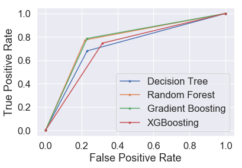

```python
# ROC커브, AUC면적 확인
# X_train, X_test, y_train, y_test
# calculate roc curves
dt_fpr, dt_tpr, _ = roc_curve(y_test, y_pred)
rf_fpr, rf_tpr, _ = roc_curve(y_test, rf_pred)
gb_fpr, gb_tpr, _ = roc_curve(y_test, gb_pred)
xgb_fpr, xgb_tpr, _ = roc_curve(y_test, xgb_pred)

# calculate scores
dt_roc_auc = roc_auc_score(y_test, y_pred) #정확도를 곡선과 면적으로 계산 할 수 있다.
rf_roc_auc = roc_auc_score(y_test, rf_pred) #정확도를 곡선과 면적으로 계산 할 수 있다.
gb_roc_auc = roc_auc_score(y_test, gb_pred) #정확도를 곡선과 면적으로 계산 할 수 있다.
xgb_roc_auc = roc_auc_score(y_test, xgb_pred) #정확도를 곡선과 면적으로 계산 할 수 있다.

print("DecisionTree: ROC_AUC=%.4f" % (dt_roc_auc))
print("RandomForest: ROC_AUC=%.4f" % (rf_roc_auc))
print("GradientBoost: ROC_AUC=%.4f" % (gb_roc_auc))
print("XGBoost: ROC_AUC=%.4f" % (xgb_roc_auc))

# plot the roc curve for the model
plt.plot(dt_fpr, dt_tpr, marker='.', label='Decision Tree')
plt.plot(rf_fpr, rf_tpr, marker='.', label='Random Forest')
plt.plot(gb_fpr, gb_tpr, marker='.', label='Gradient Boosting')
plt.plot(xgb_fpr, xgb_tpr, marker='.', label='XGBoosting')

# axis labels
plt.xlabel('False Positive Rate')
plt.ylabel('True Positive Rate')

# show the legend
plt.legend()

# show the plot
plt.show()
```

## 최종 모델 선택

##### 최종 머신러닝 모델은 ROC커브와 AUC스코어를 활용하여 채택

##### GradientBoost가 최적의 모델임